# Which variables inform classification of prevalent dental caries?

All-predictor importance, stability and a neural-network comparison in ENS 2016–17

## 1 Population and analytical question

This exploratory analysis asks **which of 44 available contextual, dietary, label-related and oral-status constructs inform classification of caries present at examination**, and how their apparent importance varies across model families and validation folds. It compares spline logistic regression, random forest, histogram gradient boosting and a two-layer neural network. A complementary scenario retains 38 constructs after excluding the six concurrent oral-status indicators.

**5,036**Dentate participants evaluated in every variant

**44**Constructs evaluated individually

**4**Model families compared

Study population.

| Population | Unweighted count |
| --- | --- |
| Survey records | 6233 |
| Complete dental examinations | 5520 |
| Edentulous participants | 484 |
| Dentate eligible participants | 5036 |
| Caries cases | 2689 |
| Participants without caries | 2347 |

Four disjoint predictor blocks.

| Block | Constructs | Content |
| --- | --- | --- |
| C17 | 17 | Sociodemographic, general-health, dental-attendance and household water context |
| D15 | 15 | Food and beverage intake, including water and estimated soda/juice volumes |
| L6 | 6 | Attention to labels, packaging information and purchase considerations |
| S6 | 6 | Concurrent oral self-rating, pain and functional/social interference |

C17+D15+L6 gives 38 constructs; adding S6 gives 44. The contextual block includes remaining teeth and dental attendance in both scenarios.

There were **2,689 observed cases**. Survey-weighted prevalence was **54.6%**; the unweighted proportion was 53.4%.

Eligibility requires an observed dental examination and at least one remaining tooth. The outcome is at least one clinically observed decayed tooth. Missing examinations are not coded caries-free, and outcomes are never imputed. The 44 constructs form the defined scope of this analysis, rather than an exhaustive inventory of every ENS measurement. Decayed-tooth counts, the outcome itself and participant identifiers never enter the predictors.

Selected quantitative characteristics by caries status.

| Measure | Units | No caries | Caries | Total |
| --- | --- | --- | --- | --- |
| Age at survey | years | 39.72 (38.51 to 40.92); n=2,347 | 43.38 (42.44 to 44.32); n=2,689 | 41.72 (40.92 to 42.51); n=5,036 |
| Total remaining teeth, upper plus lower jaw | teeth | 24.45 (24.01 to 24.88); n=2,347 | 23.08 (22.67 to 23.50); n=2,689 | 23.70 (23.39 to 24.01); n=5,036 |
| Self-reported glasses of water per day; water source/fluoride exposure not identified | glasses/day | 4.31 (4.08 to 4.53); n=2,346 | 4.13 (3.92 to 4.35); n=2,686 | 4.21 (4.05 to 4.38); n=5,032 |
| Sugar-sweetened soda consumption frequency converted to times/day | times/day | 0.73 (0.62 to 0.83); n=2,347 | 0.91 (0.76 to 1.05); n=2,689 | 0.83 (0.73 to 0.92); n=5,036 |
| Sugar-sweetened juice consumption frequency converted to times/day | times/day | 0.63 (0.52 to 0.73); n=2,347 | 0.70 (0.58 to 0.81); n=2,689 | 0.67 (0.59 to 0.75); n=5,036 |
| Estimated daily soda volume | glasses/day | 2.37 (1.63 to 3.11); n=2,345 | 3.11 (2.12 to 4.10); n=2,688 | 2.77 (2.13 to 3.42); n=5,033 |
| Estimated daily juice volume | glasses/day | 1.51 (1.21 to 1.82); n=2,346 | 1.93 (1.45 to 2.40); n=2,688 | 1.74 (1.45 to 2.03); n=5,034 |

Survey-weighted mean with 95% design-based CI; n is the unweighted observed denominator. Original measurement scales are retained. No descriptive p-value screen selects the predictors.

## 2 Development and validation

The six classical-family variants reuse their authenticated outer held-out probabilities, tuning decisions and fold metrics from the completed dietary analysis. Their candidate grids and predictions are unchanged. The two neural-network variants undergo a new bounded search fixed before these neural fits. The extension is dataset-informed: earlier results were already known, and reuse of their held-out folds does not create a new independent validation cohort.

Every variant uses five PSU-disjoint outer folds and three inner folds. Inner pooled, survey-weighted log loss selects settings. All fitted estimators receive training weights normalized to mean one. Preprocessing is learned inside each relevant training partition. Numeric predictors use median imputation with missingness indicators; categorical responses retain named levels and explicit missingness, with unknown validation levels handled by the trained encoder. MLP numeric inputs are standardized. Income remains in its questionnaire bands.

Four soda/juice frequency and volume fields retain the earlier `log1p` transformation, including valid zeros and the original extreme observations. Frequencies use seven-day weeks and 30-day months; estimated glasses per day are not grams of sugar. Water is physical glasses per day and does not establish individual fluoride exposure. Splines are applied only to age, remaining teeth and water in the spline-logistic family. No class balancing or synthetic oversampling is performed.

Model-development specifications.

| Family | Declared candidate set |
| --- | --- |
| Spline logistic | C = 0.0001, 0.001, 0.01, 0.1, 1, 10; retained nested fits |
| Random forest | 200 trees; leaf size 5, 20, 50, 100 × maximum features sqrt or 0.7; retained nested fits |
| Histogram boosting | Maximum leaves 3, 7, 15 × L2 1, 10, 100; 150 iterations; retained nested fits |
| Neural network (MLP) | ReLU layers (32,16) or (64,32) × (alpha, epochs): (1,100), (10,100), (10,250); Adam; batch 128; learning rate 0.001 |

The neural grid contains six coupled regularization/training-budget candidates. This is a bounded comparison, not an exhaustive architecture benchmark.

Neural outer-training budgets and diagnostics.

| model | fold | epochs_requested | epochs_completed | optimizer_status | n_input_columns | n_parameters |
| --- | --- | --- | --- | --- | --- | --- |
| Neural network (MLP): 38 constructs; excluding S6 | 1 | 100 | 100 | fixed_epoch_budget_completed | 161 | 12481 |
| Neural network (MLP): 38 constructs; excluding S6 | 2 | 100 | 100 | fixed_epoch_budget_completed | 162 | 5761 |
| Neural network (MLP): 38 constructs; excluding S6 | 3 | 100 | 100 | fixed_epoch_budget_completed | 162 | 5761 |
| Neural network (MLP): 38 constructs; excluding S6 | 4 | 100 | 100 | fixed_epoch_budget_completed | 162 | 12545 |
| Neural network (MLP): 38 constructs; excluding S6 | 5 | 100 | 100 | fixed_epoch_budget_completed | 162 | 12545 |
| Neural network (MLP): 44 constructs | 1 | 100 | 100 | fixed_epoch_budget_completed | 191 | 6689 |
| Neural network (MLP): 44 constructs | 2 | 250 | 250 | fixed_epoch_budget_completed | 192 | 14465 |
| Neural network (MLP): 44 constructs | 3 | 100 | 100 | fixed_epoch_budget_completed | 192 | 14465 |
| Neural network (MLP): 44 constructs | 4 | 100 | 100 | fixed_epoch_budget_completed | 192 | 6721 |
| Neural network (MLP): 44 constructs | 5 | 100 | 100 | fixed_epoch_budget_completed | 192 | 14465 |

All requested epochs must complete with finite parameters and losses. Fixed-budget completion does not claim tolerance-based optimization convergence. No internal row-based validation or validation-accuracy early stopping is used.

Performance uses survey-weighted held-out probabilities. The working examination-phase expansion weight is `Fexp_F1F2p_Corr`, numerically identical to `Fexp_F2p_Corr` in this release; confirmation against the official phase-specific manual remains outstanding. The 1,000 shared, rescaled stratified PSU-bootstrap draws retain the full positive-weight design before subsetting to the dentate domain. Intervals hold fitted models, selected settings and validation partitions fixed. Singleton strata remain fixed in this bootstrap. Descriptive profile intervals instead use ratio linearization, design-t intervals and the average-stratum convention for singleton strata. Neither convention recovers otherwise unidentified singleton variation.

## 3 Performance of the four model families

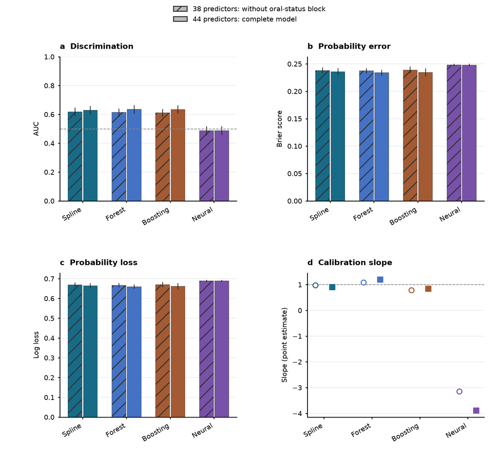

Comparison of four model families in 5,036 dentate participants. Hatched bars use 38 context, dietary and label constructs; solid bars add six concurrent oral-status indicators (44 constructs). Panels a–c show weighted held-out estimates and conditional 95% intervals from 1,000 shared stratified PSU-bootstrap draws. Panel d shows calibration-slope estimates without intervals, with open circles for 38 predictors and filled squares for 44. Reference lines are AUC 0.5 and slope 1. Higher AUC and lower Brier/log loss are desirable; a slope near one indicates less calibration distortion. These are exploratory internally validated classification results, with all preprocessing and tuning inside training partitions. Neural pooled slopes are sensitive to small between-fold shifts because the fitted neural probabilities are nearly constant within folds. No outer results were used to choose a model.

Performance with all 44 constructs.

| Model | AUC (95% CI) | Brier (95% CI) | Log loss (95% CI) |
| --- | --- | --- | --- |
| Spline logistic: 44 constructs | 0.630 (0.601 to 0.659) | 0.2360 (0.2299 to 0.2422) | 0.6646 (0.6514 to 0.6779) |
| Random forest: 44 constructs | 0.637 (0.605 to 0.666) | 0.2341 (0.2287 to 0.2395) | 0.6602 (0.6489 to 0.6716) |
| Histogram boosting: 44 constructs | 0.635 (0.605 to 0.664) | 0.2347 (0.2275 to 0.2420) | 0.6619 (0.6462 to 0.6772) |
| Neural network (MLP): 44 constructs | 0.488 (0.457 to 0.519) | 0.2481 (0.2457 to 0.2505) | 0.6893 (0.6845 to 0.6941) |

AUC is better when higher; Brier score and log loss are better when lower. The 95% intervals are conditional survey-bootstrap intervals on the same participants.

Training-fold prevalence benchmark.

| Model | AUC (95% CI) | Brier (95% CI) | Log loss (95% CI) |
| --- | --- | --- | --- |
| Training-fold prevalence benchmark | 0.477 (0.445 to 0.506) | 0.2481 (0.2457 to 0.2505) | 0.6893 (0.6844 to 0.6942) |

Each held-out participant receives the prevalence from the corresponding training partition. The pooled calibration slope of this within-fold constant benchmark is not interpreted.

An AUC of 0.5 is a chance-ranking reference; an AUC above it does not establish accurate or useful individual predictions. Brier score and log loss assess probability accuracy, while calibration assesses agreement between probabilities and observed outcomes. All four families are retained in the interpretation. No family becomes the primary analysis because it achieves the largest observed outer AUC.

## 4 Individual contributions across all 44 constructs

Each raw predictor is permuted on outer held-out participants before model preprocessing, linking its encoded categories and missingness representation. Five donor permutations per variable per fold follow the same deterministic convention across families. Recipient outcomes and expansion weights stay fixed. Repeat changes are averaged within fold, then fold means are weighted by held-out expansion totals. Brier increase leads the display and AUC decrease complements it: positive values indicate worse performance after perturbation.

Spline and random-forest importances are reused. The ten boosting outer fits are reconstructed solely to obtain their missing importances, with the original selected settings and seeds; reconstructed probabilities must match archived probabilities within absolute tolerance 1e-12 before permutation. Neural importance uses its newly selected outer-training fits. No classical family is retuned for this extension.

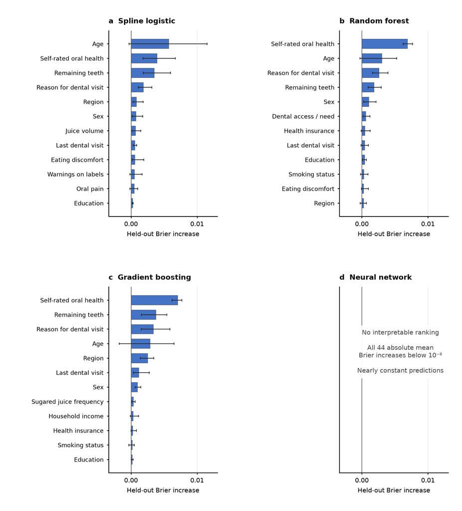

Individual predictor importance in the 44 predictors scenario. The 12 largest signed mean importances are shown separately within each family; their selection is descriptive and is not predictor screening. All 44 constructs remain fitted and their complete signed results are tabulated. Blue horizontal bars preserve the visual line of the earlier manuscript. Bars are means of held-out Brier increases after marginal permutation of each raw variable, with five perturbations per outer fold and weighting by fold expansion totals. Whiskers are the minimum and maximum fold means, not confidence intervals. A positive value indicates deterioration after perturbation; a negative value indicates improvement. Correlated predictors may share information, and permutation can create unusual combinations. The scores describe reliance of these fitted classifiers, not causal effects, protective directions or percentages of disease explained. Neural results below absolute mean Brier 10⁻⁸ are marked as numerically near zero; this reporting rule was adopted after observing nearly constant predictions and is not a significance threshold. Neural ranks, sign fractions and AUC permutation scores are not interpreted; all raw signed values remain available in the supplementary results.

Ten leading mean permutation contributions in the full models with discernible magnitudes.

| Model | Variable | Description | Mean Brier increase | Fold minimum | Fold maximum | Mean AUC decrease | Rank by mean Brier increase | Median fold rank | Fraction of positive folds | Fraction among fold top ten |
| --- | --- | --- | --- | --- | --- | --- | --- | --- | --- | --- |
| Spline logistic: 44 constructs | age | Age at survey | 0.005709 | -0.000324 | 0.011492 | 0.0309 | 1.0 | 1.0 | 0.8 | 0.8 |
| Spline logistic: 44 constructs | oral_health_selfrating | Overall self-rated oral health | 0.003928 | 0.001787 | 0.006681 | 0.0193 | 2.0 | 3.0 | 1.0 | 1.0 |
| Spline logistic: 44 constructs | teeth_remaining | Total remaining teeth, upper plus lower jaw | 0.003504 | 0.001830 | 0.005976 | 0.0185 | 3.0 | 2.0 | 1.0 | 1.0 |
| Spline logistic: 44 constructs | dental_visit_reason | Main reason for the most recent dental visit | 0.001872 | 0.001109 | 0.003146 | 0.0095 | 4.0 | 4.0 | 1.0 | 1.0 |
| Spline logistic: 44 constructs | region | Survey region (2016 boundaries) | 0.000796 | 0.000286 | 0.001837 | 0.0039 | 5.0 | 7.0 | 1.0 | 0.8 |
| Spline logistic: 44 constructs | sex | Recorded sex | 0.000754 | 0.000137 | 0.001771 | 0.0035 | 6.0 | 9.0 | 1.0 | 0.6 |
| Spline logistic: 44 constructs | juice_glasses_daily | Estimated daily juice volume | 0.000669 | 0.000149 | 0.001456 | 0.0023 | 7.0 | 8.0 | 1.0 | 0.6 |
| Spline logistic: 44 constructs | dental_visit | Time since last dental visit | 0.000573 | 0.000305 | 0.000850 | 0.0028 | 8.0 | 9.0 | 1.0 | 0.8 |
| Spline logistic: 44 constructs | oral_eating | Frequency of discomfort from teeth or dentures when eating | 0.000570 | 0.000151 | 0.001928 | 0.0023 | 9.0 | 13.0 | 1.0 | 0.4 |
| Spline logistic: 44 constructs | label_warnings | Frequency of checking/considering package warnings | 0.000508 | -0.000183 | 0.001660 | 0.0005 | 10.0 | 10.0 | 0.6 | 0.6 |
| Random forest: 44 constructs | oral_health_selfrating | Overall self-rated oral health | 0.006881 | 0.006252 | 0.007639 | 0.0427 | 1.0 | 1.0 | 1.0 | 1.0 |
| Random forest: 44 constructs | age | Age at survey | 0.003016 | -0.000299 | 0.005249 | 0.0149 | 2.0 | 2.0 | 0.8 | 0.8 |
| Random forest: 44 constructs | dental_visit_reason | Main reason for the most recent dental visit | 0.002585 | 0.001617 | 0.003922 | 0.0139 | 3.0 | 3.0 | 1.0 | 1.0 |
| Random forest: 44 constructs | teeth_remaining | Total remaining teeth, upper plus lower jaw | 0.001838 | 0.000934 | 0.002920 | 0.0089 | 4.0 | 4.0 | 1.0 | 1.0 |
| Random forest: 44 constructs | sex | Recorded sex | 0.001045 | 0.000264 | 0.002116 | 0.0049 | 5.0 | 6.0 | 1.0 | 0.8 |
| Random forest: 44 constructs | dental_access | Dental care received or unmet need during the previous six months | 0.000586 | 0.000185 | 0.001192 | 0.0023 | 6.0 | 9.0 | 1.0 | 0.8 |
| Random forest: 44 constructs | health_insurance | Participant's health insurance system, including public insurance group | 0.000444 | -0.000124 | 0.001237 | 0.0017 | 7.0 | 10.0 | 0.8 | 0.6 |
| Random forest: 44 constructs | dental_visit | Time since last dental visit | 0.000415 | -0.000134 | 0.000988 | 0.0003 | 8.0 | 12.0 | 0.8 | 0.2 |
| Random forest: 44 constructs | education | Low <8, intermediate 8–12, high >=13 years of schooling | 0.000412 | 0.000089 | 0.000669 | 0.0013 | 9.0 | 10.0 | 1.0 | 0.6 |
| Random forest: 44 constructs | smoking_status | Self-reported current daily, occasional, former or never cigarette smoking | 0.000295 | -0.000203 | 0.000906 | 0.0011 | 10.0 | 16.0 | 0.8 | 0.4 |
| Histogram boosting: 44 constructs | oral_health_selfrating | Overall self-rated oral health | 0.007063 | 0.006192 | 0.007676 | 0.0375 | 1.0 | 1.0 | 1.0 | 1.0 |
| Histogram boosting: 44 constructs | teeth_remaining | Total remaining teeth, upper plus lower jaw | 0.003748 | 0.001569 | 0.005400 | 0.0191 | 2.0 | 3.0 | 1.0 | 1.0 |
| Histogram boosting: 44 constructs | dental_visit_reason | Main reason for the most recent dental visit | 0.003356 | 0.001523 | 0.005860 | 0.0167 | 3.0 | 2.0 | 1.0 | 1.0 |
| Histogram boosting: 44 constructs | age | Age at survey | 0.002874 | -0.001791 | 0.006489 | 0.0150 | 4.0 | 3.0 | 0.8 | 0.8 |
| Histogram boosting: 44 constructs | region | Survey region (2016 boundaries) | 0.002513 | 0.001392 | 0.003438 | 0.0128 | 5.0 | 5.0 | 1.0 | 1.0 |
| Histogram boosting: 44 constructs | dental_visit | Time since last dental visit | 0.001159 | 0.000360 | 0.002741 | 0.0056 | 6.0 | 7.0 | 1.0 | 1.0 |
| Histogram boosting: 44 constructs | sex | Recorded sex | 0.000981 | 0.000611 | 0.001468 | 0.0053 | 7.0 | 6.0 | 1.0 | 1.0 |
| Histogram boosting: 44 constructs | juice_frequency | Sugar-sweetened juice consumption frequency converted to times/day | 0.000355 | 0.000098 | 0.000619 | 0.0018 | 8.0 | 10.0 | 1.0 | 0.6 |
| Histogram boosting: 44 constructs | income_band | Monthly net income of the entire household, in questionnaire bands | 0.000324 | -0.000117 | 0.001147 | 0.0024 | 9.0 | 13.0 | 0.8 | 0.4 |
| Histogram boosting: 44 constructs | health_insurance | Participant's health insurance system, including public insurance group | 0.000233 | -0.000018 | 0.000802 | 0.0024 | 10.0 | 13.0 | 0.8 | 0.2 |

A descriptive ordering of signed model reliance. Fold minimum–maximum values are stability ranges, not 95% confidence limits. Complete results retain all weak, zero and negative estimates below. Models with all absolute mean Brier changes below 1e-8 are retained in performance but their numerical ranks are not interpreted.

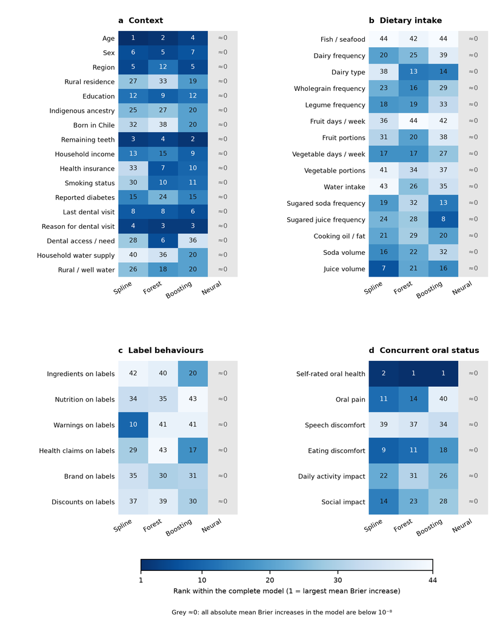

Ranks of all 44 predictors in the complete models, displayed by questionnaire block. Each column ranks the same 44 raw constructs within one family using weighted mean held-out Brier permutation increase; rank 1 is the largest signed score and ties receive their minimum rank. The common 1–44 scale is ordinal: differences in rank are not equal differences in predictive information. A rank does not establish a positive importance or statistical significance. Signed magnitudes are provided in Table 3 and complete fold-stability results in the supplement. Grey cells mark models whose absolute mean Brier importances are all below 10⁻⁸; ranks at that scale are not interpreted. This is a presentation rule applied after observing the near-constant neural predictions, not a significance threshold or a model-selection rule. The raw signed scores and computed ranks remain in the aggregate tables. Water, label behaviours and concurrent symptoms remain visible irrespective of their rank.

Water alongside the full set of predictors.

| Model | Variable | Description | Mean Brier increase | Fold minimum | Fold maximum | Mean AUC decrease | Rank by mean Brier increase | Median fold rank | Fraction of positive folds | Fraction among fold top ten |
| --- | --- | --- | --- | --- | --- | --- | --- | --- | --- | --- |
| Histogram boosting: 44 constructs | water | Self-reported glasses of water per day; water source/fluoride exposure not identified | -0.000133 | -0.000466 | 0.000019 | -0.0003 | 35.0 | 37.0 | 0.2 | 0.0 |
| Neural network (MLP): 44 constructs | water | Self-reported glasses of water per day; water source/fluoride exposure not identified | 1.809e-12 | -2.021e-15 | 6.624e-12 | Not interpreted: negligible probability variation | Not interpreted: negligible magnitude | Not interpreted: negligible magnitude | Not interpreted: negligible magnitude | Not interpreted: negligible magnitude |
| Random forest: 44 constructs | water | Self-reported glasses of water per day; water source/fluoride exposure not identified | 0.000002 | -0.000202 | 0.000492 | -0.0001 | 26.0 | 29.0 | 0.2 | 0.2 |
| Spline logistic: 44 constructs | water | Self-reported glasses of water per day; water source/fluoride exposure not identified | -0.000437 | -0.001268 | 0.000015 | -0.0018 | 43.0 | 37.0 | 0.2 | 0.0 |

Water is neither forced into the leading ranks nor omitted because its contribution is small. Permutation importance does not identify a protective direction or a causal effect.

Permutation importance is specific to the fitted model, its correlated predictors and the chosen perturbation. It does not estimate a uniquely independent exposure contribution or the percentage of caries explained. Correlated predictors can share predictive information; shuffling one can create combinations rarely seen in the survey. This issue is particularly relevant to beverage frequencies and their derived volumes.

## 5 Joint blocks and stability across models

Joint-block permutation uses one donor row for every variable within that block, preserving their within-block combinations. Context, diet, labels and oral status are disjoint, but their block sizes differ. A block’s permutation contribution is neither the sum of individual contributions nor the gain from refitting a model with or without that block.

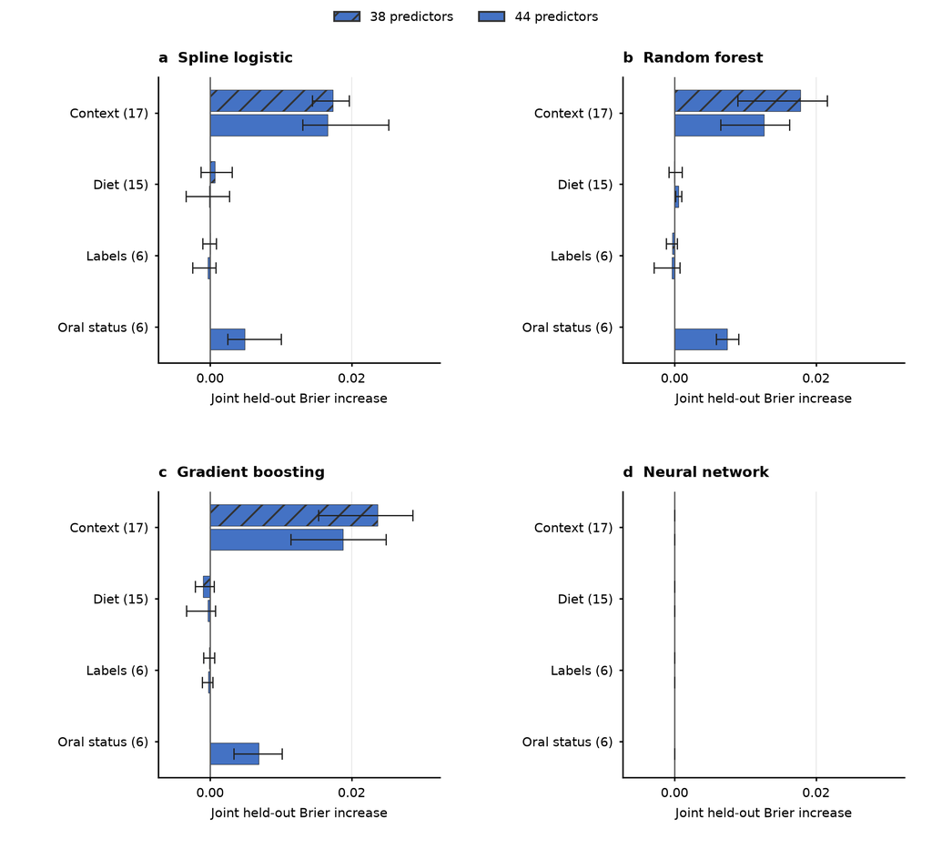

Joint importance of the four predictor blocks in each model family. A single donor-row permutation moves all raw variables of a block together, preserving internal combinations. Hatched bars use 38 predictors and solid bars use 44; oral-status information is absent from the 38-predictor scenario. Bars are weighted averages of fold means and whiskers span minimum–maximum fold means over five outer folds, with five perturbations per block per fold. Ranges are not confidence intervals. The common signed axis preserves negative estimates. Block sizes differ; scores are not additive, are not percentages explained, and do not measure improvement from refitting after removing a block.

Joint block contributions in the full models.

| Model | block | brier_increase | minimum_fold_brier_increase | maximum_fold_brier_increase | auc_drop | fraction_positive_folds |
| --- | --- | --- | --- | --- | --- | --- |
| Histogram boosting: 44 constructs | context | 0.018781 | 0.011433 | 0.024840 | 0.094635 | 1.0 |
| Histogram boosting: 44 constructs | diet | -0.000334 | -0.003345 | 0.000728 | 0.00097 | 0.6 |
| Histogram boosting: 44 constructs | labels | -0.000257 | -0.001111 | 0.000354 | -0.000805 | 0.6 |
| Histogram boosting: 44 constructs | symptoms | 0.006871 | 0.003367 | 0.010170 | 0.035061 | 1.0 |
| Neural network (MLP): 44 constructs | context | 0.000000 | -0.000000 | 0.000000 | Not interpreted: negligible magnitude | Not interpreted: negligible magnitude |
| Neural network (MLP): 44 constructs | diet | 0.000000 | -0.000000 | 0.000000 | Not interpreted: negligible magnitude | Not interpreted: negligible magnitude |
| Neural network (MLP): 44 constructs | labels | 0.000000 | -0.000000 | 0.000000 | Not interpreted: negligible magnitude | Not interpreted: negligible magnitude |
| Neural network (MLP): 44 constructs | symptoms | 0.000000 | -0.000000 | 0.000000 | Not interpreted: negligible magnitude | Not interpreted: negligible magnitude |
| Random forest: 44 constructs | context | 0.012673 | 0.006530 | 0.016217 | 0.080894 | 1.0 |
| Random forest: 44 constructs | diet | 0.000560 | 0.000158 | 0.000980 | 0.001577 | 1.0 |
| Random forest: 44 constructs | labels | -0.000353 | -0.002885 | 0.000773 | -0.004794 | 0.6 |
| Random forest: 44 constructs | symptoms | 0.007441 | 0.005901 | 0.009041 | 0.046873 | 1.0 |
| Spline logistic: 44 constructs | context | 0.016630 | 0.013088 | 0.025248 | 0.093053 | 1.0 |
| Spline logistic: 44 constructs | diet | -0.000134 | -0.003436 | 0.002714 | 0.001676 | 0.6 |
| Spline logistic: 44 constructs | labels | -0.000288 | -0.002464 | 0.000820 | -0.001934 | 0.6 |
| Spline logistic: 44 constructs | symptoms | 0.004889 | 0.002493 | 0.010038 | 0.022684 | 1.0 |

Signed changes and descriptive fold ranges. Different block sizes and dependencies limit direct attribution comparisons.

Agreement across the three classical full models for every construct.

| feature | Description | classical_models | classical_models_with_positive_mean | classical_models_positive_in_at_least_four_folds | classical_models_in_top10 | classical_median_overall_rank | classical_best_overall_rank | classical_worst_overall_rank |
| --- | --- | --- | --- | --- | --- | --- | --- | --- |
| oral_health_selfrating | Overall self-rated oral health | 3 | 3 | 3 | 3 | 1.0 | 1.0 | 2.0 |
| age | Age at survey | 3 | 3 | 3 | 3 | 2.0 | 1.0 | 4.0 |
| dental_visit_reason | Main reason for the most recent dental visit | 3 | 3 | 3 | 3 | 3.0 | 3.0 | 4.0 |
| teeth_remaining | Total remaining teeth, upper plus lower jaw | 3 | 3 | 3 | 3 | 3.0 | 2.0 | 4.0 |
| region | Survey region (2016 boundaries) | 3 | 3 | 2 | 2 | 5.0 | 5.0 | 12.0 |
| sex | Recorded sex | 3 | 3 | 3 | 3 | 6.0 | 5.0 | 7.0 |
| dental_visit | Time since last dental visit | 3 | 3 | 3 | 3 | 8.0 | 6.0 | 8.0 |
| health_insurance | Participant's health insurance system, including public insurance group | 3 | 2 | 2 | 2 | 10.0 | 7.0 | 33.0 |
| oral_eating | Frequency of discomfort from teeth or dentures when eating | 3 | 3 | 2 | 1 | 11.0 | 9.0 | 18.0 |
| smoking_status | Self-reported current daily, occasional, former or never cigarette smoking | 3 | 2 | 2 | 1 | 11.0 | 10.0 | 30.0 |
| education | Low <8, intermediate 8–12, high >=13 years of schooling | 3 | 3 | 3 | 1 | 12.0 | 9.0 | 12.0 |
| income_band | Monthly net income of the entire household, in questionnaire bands | 3 | 3 | 3 | 1 | 13.0 | 9.0 | 15.0 |
| dairy_type | Usual dairy fat content, with structural category for nonconsumers | 3 | 2 | 0 | 0 | 14.0 | 13.0 | 38.0 |
| oral_pain | Frequency of suffering or pain attributed to teeth or dentures | 3 | 2 | 1 | 0 | 14.0 | 11.0 | 40.0 |
| diabetes_reported | Ever told by a health professional that the participant had diabetes | 3 | 3 | 1 | 0 | 15.0 | 15.0 | 24.0 |
| juice_glasses_daily | Estimated daily juice volume | 3 | 3 | 2 | 1 | 16.0 | 7.0 | 21.0 |
| vegetable_days | Vegetable consumption days in a typical week | 3 | 2 | 2 | 0 | 17.0 | 17.0 | 27.0 |
| legumes | Legume consumption frequency | 3 | 2 | 1 | 0 | 19.0 | 18.0 | 33.0 |
| soda_frequency | Sugar-sweetened soda consumption frequency converted to times/day | 3 | 2 | 0 | 0 | 19.0 | 13.0 | 32.0 |
| rural_water_consumption | Consumed well, spring or rural drinking water during the previous week for drinking/cooking; not bottled water or fluoride concentration | 3 | 1 | 1 | 0 | 20.0 | 18.0 | 26.0 |
| oil | Most frequently used cooking oil/fat | 3 | 1 | 0 | 0 | 21.0 | 20.0 | 29.0 |
| soda_glasses_daily | Estimated daily soda volume | 3 | 2 | 0 | 0 | 22.0 | 16.0 | 32.0 |
| oral_social | Frequency of interference with social relationships from teeth or dentures | 3 | 2 | 1 | 0 | 23.0 | 14.0 | 28.0 |
| wholegrain | Wholegrain consumption frequency | 3 | 2 | 0 | 0 | 23.0 | 16.0 | 29.0 |
| juice_frequency | Sugar-sweetened juice consumption frequency converted to times/day | 3 | 2 | 3 | 1 | 24.0 | 8.0 | 28.0 |
| dairy_frequency | Dairy consumption frequency | 3 | 2 | 0 | 0 | 25.0 | 20.0 | 39.0 |
| indigenous | Self-reported membership/ancestry of a recognized indigenous people | 3 | 0 | 0 | 0 | 25.0 | 20.0 | 27.0 |
| oral_daily_activities | Frequency of interference with daily activities from teeth or dentures | 3 | 1 | 1 | 0 | 26.0 | 22.0 | 31.0 |
| rural | Urban/rural residence | 3 | 1 | 0 | 0 | 27.0 | 19.0 | 33.0 |
| dental_access | Dental care received or unmet need during the previous six months | 3 | 1 | 1 | 1 | 28.0 | 6.0 | 36.0 |
| label_health | Frequency of checking/considering package health | 3 | 1 | 0 | 0 | 29.0 | 17.0 | 43.0 |
| fruit_portions | Fruit portions on a consumption day; zero for nonconsumers | 3 | 1 | 0 | 0 | 31.0 | 20.0 | 38.0 |
| label_brand | Frequency of checking/considering package brand | 3 | 0 | 0 | 0 | 31.0 | 30.0 | 35.0 |
| born_chile | Born in Chile | 3 | 0 | 0 | 0 | 32.0 | 20.0 | 38.0 |
| label_nutrition | Frequency of checking/considering package nutrition | 3 | 0 | 0 | 0 | 35.0 | 34.0 | 43.0 |
| water | Self-reported glasses of water per day; water source/fluoride exposure not identified | 3 | 1 | 0 | 0 | 35.0 | 26.0 | 43.0 |
| household_water_source | Household supply: public network vs other; not a measure of fluoride exposure | 3 | 0 | 0 | 0 | 36.0 | 20.0 | 40.0 |
| label_discounts | Frequency of checking/considering package discounts | 3 | 0 | 0 | 0 | 37.0 | 30.0 | 39.0 |
| oral_speech | Frequency of discomfort from teeth or dentures when speaking | 3 | 0 | 0 | 0 | 37.0 | 34.0 | 39.0 |
| vegetable_portions | Vegetable portions on a consumption day; zero for nonconsumers | 3 | 0 | 0 | 0 | 37.0 | 34.0 | 41.0 |
| label_ingredients | Frequency of checking/considering package ingredients | 3 | 0 | 0 | 0 | 40.0 | 20.0 | 42.0 |
| label_warnings | Frequency of checking/considering package warnings | 3 | 1 | 0 | 1 | 41.0 | 10.0 | 41.0 |
| fruit_days | Fruit consumption days in a typical week | 3 | 0 | 0 | 0 | 42.0 | 36.0 | 44.0 |
| fish | Fish/seafood consumption frequency | 3 | 0 | 0 | 0 | 44.0 | 42.0 | 44.0 |

The MLP is omitted only from this interpretive ranking summary because its contributions are practically zero under the fitted procedure. All four-model numeric summaries remain below and in CSV. Positive means and top-ten counts are descriptive, not significance tests or causal rankings. Minimum-rank ties can include more than ten variables at a boundary.

In this completed run, the neural benchmark produces practically zero Brier contributions for every variable. Its numerical ranks and signs therefore do not identify informative variables; tiny arithmetic differences can change the signs of fold averages. The visual rule marking all absolute mean Brier changes below 1e-8 was introduced after inspecting this result and is solely a presentation rule, not a significance threshold or a reason to alter the model search. The classical-only agreement view is explicitly labelled; the neural performance and raw contribution outputs remain available.

Rank differences and fold ranges show sensitivity to the training sample and the model family. They are not independent replications of the study, and the five permutation repeats do not multiply the effective sample size. A consistent positive contribution is stronger descriptive evidence of model reliance than a high rank that appears in one family or one fold. It still requires scientific interpretation and independent validation.

## 6 Calibration and the complementary 38-construct scenario

The 38-construct scenario excludes S6 but retains dental attendance and examined remaining teeth. Comparing 44 versus 38 asks about concurrent oral-status information under each development procedure. It does not identify mediation, biological effects or future caries risk. The MLP comparisons with each classical family are exploratory and paired on the same participants; there is no multiplicity-adjusted confirmatory claim.

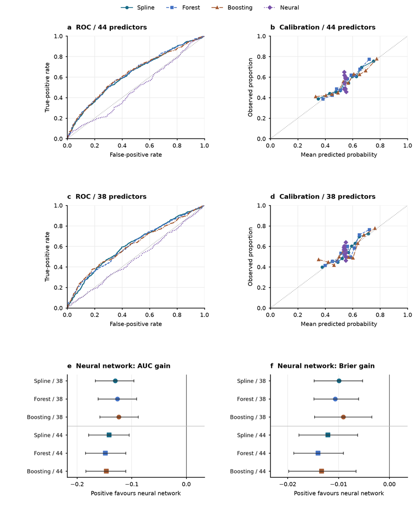

ROC and calibration displays for the complete 44-predictor models (a–b) and the 38-predictor complementary models (c–d). Calibration points use deciles of held-out predictions with weighted mean predicted and observed proportions; lines are descriptive and do not carry intervals. The diagonal is the reference for chance discrimination or ideal calibration. Panels e–f compare the neural network with each classical family on identical held-out participants. Labels identify the reference family and number of constructs. Positive AUC gain or reference-minus-neural Brier gain favours the neural model. Whiskers are paired conditional 95% intervals from 1,000 shared PSU-bootstrap draws, with fitted models and tuning decisions held fixed. All comparisons are exploratory.

Complementary performance excluding the six oral-status indicators.

| Model | AUC (95% CI) | Brier (95% CI) | Log loss (95% CI) |
| --- | --- | --- | --- |
| Spline logistic: 38 constructs; excluding S6 | 0.618 (0.590 to 0.647) | 0.2383 (0.2330 to 0.2437) | 0.6691 (0.6581 to 0.6805) |
| Random forest: 38 constructs; excluding S6 | 0.614 (0.585 to 0.642) | 0.2375 (0.2324 to 0.2424) | 0.6672 (0.6562 to 0.6773) |
| Histogram boosting: 38 constructs; excluding S6 | 0.612 (0.583 to 0.639) | 0.2391 (0.2328 to 0.2452) | 0.6705 (0.6571 to 0.6839) |
| Neural network (MLP): 38 constructs; excluding S6 | 0.488 (0.455 to 0.519) | 0.2482 (0.2458 to 0.2505) | 0.6895 (0.6847 to 0.6942) |

Neural network versus each classical family.

| Compared model | Reference | Brier gain (95% CI) | AUC gain (95% CI) | Log-loss gain (95% CI) |
| --- | --- | --- | --- | --- |
| Neural network (MLP): 38 constructs; excluding S6 | Spline logistic: 38 constructs; excluding S6 | -0.009898 (-0.014811 to -0.005278) | -0.1302 (-0.1665 to -0.0961) | -0.020336 (-0.030697 to -0.010536) |
| Neural network (MLP): 38 constructs; excluding S6 | Random forest: 38 constructs; excluding S6 | -0.010654 (-0.014851 to -0.006086) | -0.1263 (-0.1617 to -0.0910) | -0.022303 (-0.031149 to -0.012747) |
| Neural network (MLP): 38 constructs; excluding S6 | Histogram boosting: 38 constructs; excluding S6 | -0.009080 (-0.014725 to -0.003450) | -0.1236 (-0.1583 to -0.0882) | -0.018949 (-0.030809 to -0.006961) |
| Neural network (MLP): 44 constructs | Spline logistic: 44 constructs | -0.012088 (-0.017818 to -0.006281) | -0.1414 (-0.1788 to -0.1049) | -0.024714 (-0.036877 to -0.012127) |
| Neural network (MLP): 44 constructs | Random forest: 44 constructs | -0.014022 (-0.018824 to -0.009069) | -0.1482 (-0.1847 to -0.1111) | -0.029127 (-0.039115 to -0.018925) |
| Neural network (MLP): 44 constructs | Histogram boosting: 44 constructs | -0.013336 (-0.019830 to -0.006587) | -0.1464 (-0.1840 to -0.1109) | -0.027430 (-0.041318 to -0.012787) |

Positive AUC gain is compared minus reference; positive Brier and log-loss gains are reference minus compared. These 95% intervals condition on the fitted models and partitions.

All 44 versus 38 constructs within each family.

| Compared model | Reference | Brier gain (95% CI) | AUC gain (95% CI) | Log-loss gain (95% CI) |
| --- | --- | --- | --- | --- |
| Spline logistic: 44 constructs | Spline logistic: 38 constructs; excluding S6 | 0.002264 (-0.000211 to 0.004573) | 0.0114 (0.0004 to 0.0226) | 0.004529 (-0.001090 to 0.009761) |
| Random forest: 44 constructs | Random forest: 38 constructs; excluding S6 | 0.003443 (0.000674 to 0.006217) | 0.0222 (0.0040 to 0.0393) | 0.006975 (0.001361 to 0.012728) |
| Histogram boosting: 44 constructs | Histogram boosting: 38 constructs; excluding S6 | 0.004330 (0.001319 to 0.007182) | 0.0231 (0.0092 to 0.0365) | 0.008632 (0.002159 to 0.014843) |
| Neural network (MLP): 44 constructs | Neural network (MLP): 38 constructs; excluding S6 | 0.000075 (-0.000045 to 0.000190) | 0.0002 (-0.0160 to 0.0161) | 0.000151 (-0.000091 to 0.000383) |

These contrasts include the effect of the independently selected training settings for each information scenario.

Pooled held-out calibration.

| Model | Calibration-in-the-large | Calibration slope | Status |
| --- | --- | --- | --- |
| Spline logistic: 44 constructs | 0.001 | 0.907 | Estimated |
| Random forest: 44 constructs | 0.006 | 1.200 | Estimated |
| Histogram boosting: 44 constructs | 0.001 | 0.844 | Estimated |
| Neural network (MLP): 44 constructs | 0.004 | -3.892 | Estimated |
| Spline logistic: 38 constructs; excluding S6 | 0.003 | 0.979 | Estimated |
| Random forest: 38 constructs; excluding S6 | 0.013 | 1.082 | Estimated |
| Histogram boosting: 38 constructs; excluding S6 | 0.003 | 0.781 | Estimated |
| Neural network (MLP): 38 constructs; excluding S6 | 0.005 | -3.147 | Estimated |

Intercept target 0 and slope target 1. Estimates and curves are descriptive; no calibration-parameter confidence intervals or deployment recalibration are claimed.

## 7 Interpretation and limitations

The contribution analysis evaluates all 44 defined constructs and preserves their weak or unstable findings. Its scientific value is the identification of information that models use consistently, accompanied by honest assessment of discrimination, probability accuracy and calibration. It does not establish determinants of caries or justify selecting exposures by an importance threshold.

Concurrent oral self-rating, pain, dental attendance and treatment-related responses may be consequences of existing disease. The use of remaining teeth also means neither scenario represents a fully remote questionnaire-only screening tool. No future-incidence prediction, external validation, clinical decision threshold or net benefit has been established. The available measurements lack verified brushing, toothpaste/fluoride, flossing and xerostomia constructs; water quantity and household source do not substitute for individual fluoride exposure.

A two-layer MLP adds a specified neural family, not a comprehensive test of deep learning. Tabular benchmark studies support comparing networks with strong conventional baselines rather than assuming a neural advantage. Grinsztajn and colleagues found competitive tree performance across 45 medium-sized tabular datasets; McElfresh and colleagues showed that relative performance across 19 algorithms and 176 datasets depended on tuning and dataset characteristics. These benchmarks do not directly validate performance in this complex survey. [NeurIPS 2022 original study](https://proceedings.neurips.cc/paper_files/paper/2022/file/0378c7692da36807bdec87ab043cdadc-Paper-Datasets_and_Benchmarks.pdf); [NeurIPS 2023 original study](https://papers.neurips.cc/paper_files/paper/2023/file/f06d5ebd4ff40b40dd97e30cee632123-Paper-Datasets_and_Benchmarks.pdf).

The fixed neural search may not identify an optimal architecture. Reaching its epoch budget is not proof of convergence, while poor performance in this bounded procedure would not establish that all neural approaches fail. No architecture, seed, preprocessing change or new covariate is added after inspecting its outer performance. This extension remains exploratory because the same dataset and earlier findings informed its design.

## 8 Supplementary results

### 8.1 Complete importance by domain and scenario

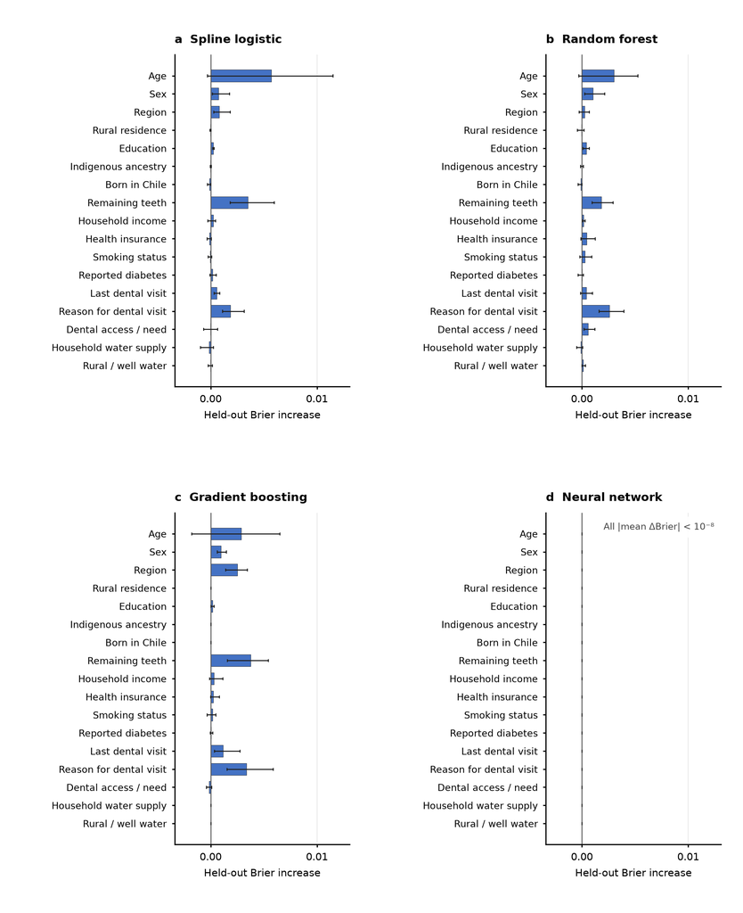

Individual predictor importance in the 44 predictors scenario. Every construct in the indicated block is shown in questionnaire order, including zero and negative values. Blue horizontal bars preserve the visual line of the earlier manuscript. Bars are means of held-out Brier increases after marginal permutation of each raw variable, with five perturbations per outer fold and weighting by fold expansion totals. Whiskers are the minimum and maximum fold means, not confidence intervals. A positive value indicates deterioration after perturbation; a negative value indicates improvement. Correlated predictors may share information, and permutation can create unusual combinations. The scores describe reliance of these fitted classifiers, not causal effects, protective directions or percentages of disease explained. Neural results below absolute mean Brier 10⁻⁸ are marked as numerically near zero; this reporting rule was adopted after observing nearly constant predictions and is not a significance threshold. Neural ranks, sign fractions and AUC permutation scores are not interpreted; all raw signed values remain available in the supplementary results.

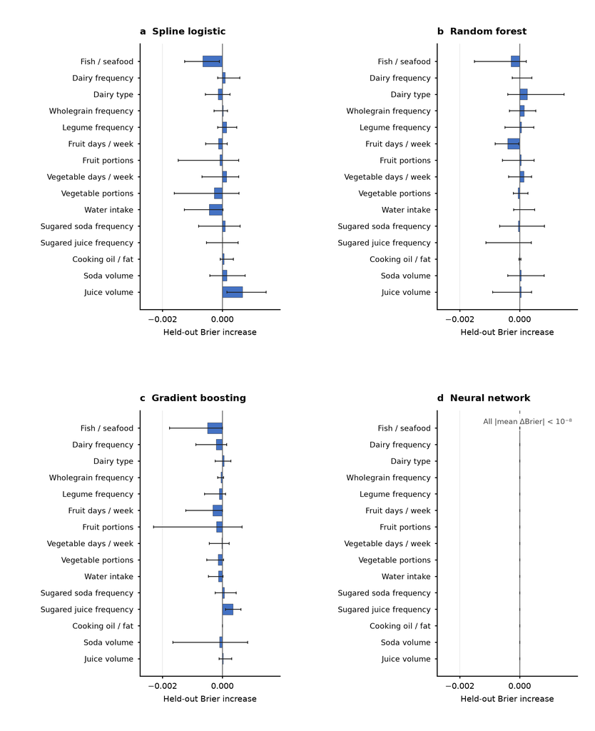

Individual predictor importance in the 44 predictors scenario. Every construct in the indicated block is shown in questionnaire order, including zero and negative values. Blue horizontal bars preserve the visual line of the earlier manuscript. Bars are means of held-out Brier increases after marginal permutation of each raw variable, with five perturbations per outer fold and weighting by fold expansion totals. Whiskers are the minimum and maximum fold means, not confidence intervals. A positive value indicates deterioration after perturbation; a negative value indicates improvement. Correlated predictors may share information, and permutation can create unusual combinations. The scores describe reliance of these fitted classifiers, not causal effects, protective directions or percentages of disease explained. Neural results below absolute mean Brier 10⁻⁸ are marked as numerically near zero; this reporting rule was adopted after observing nearly constant predictions and is not a significance threshold. Neural ranks, sign fractions and AUC permutation scores are not interpreted; all raw signed values remain available in the supplementary results.

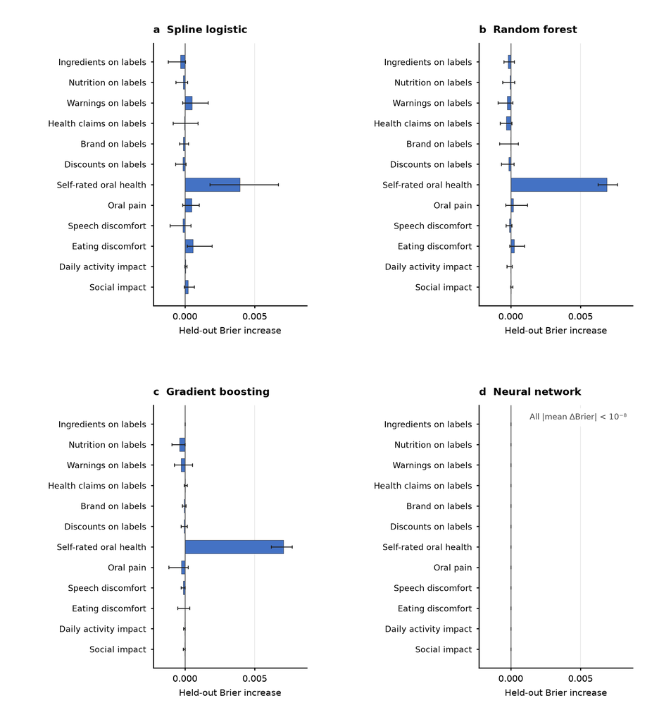

Individual predictor importance in the 44 predictors scenario. Every construct in the indicated block is shown in questionnaire order, including zero and negative values. Blue horizontal bars preserve the visual line of the earlier manuscript. Bars are means of held-out Brier increases after marginal permutation of each raw variable, with five perturbations per outer fold and weighting by fold expansion totals. Whiskers are the minimum and maximum fold means, not confidence intervals. A positive value indicates deterioration after perturbation; a negative value indicates improvement. Correlated predictors may share information, and permutation can create unusual combinations. The scores describe reliance of these fitted classifiers, not causal effects, protective directions or percentages of disease explained. Neural results below absolute mean Brier 10⁻⁸ are marked as numerically near zero; this reporting rule was adopted after observing nearly constant predictions and is not a significance threshold. Neural ranks, sign fractions and AUC permutation scores are not interpreted; all raw signed values remain available in the supplementary results.

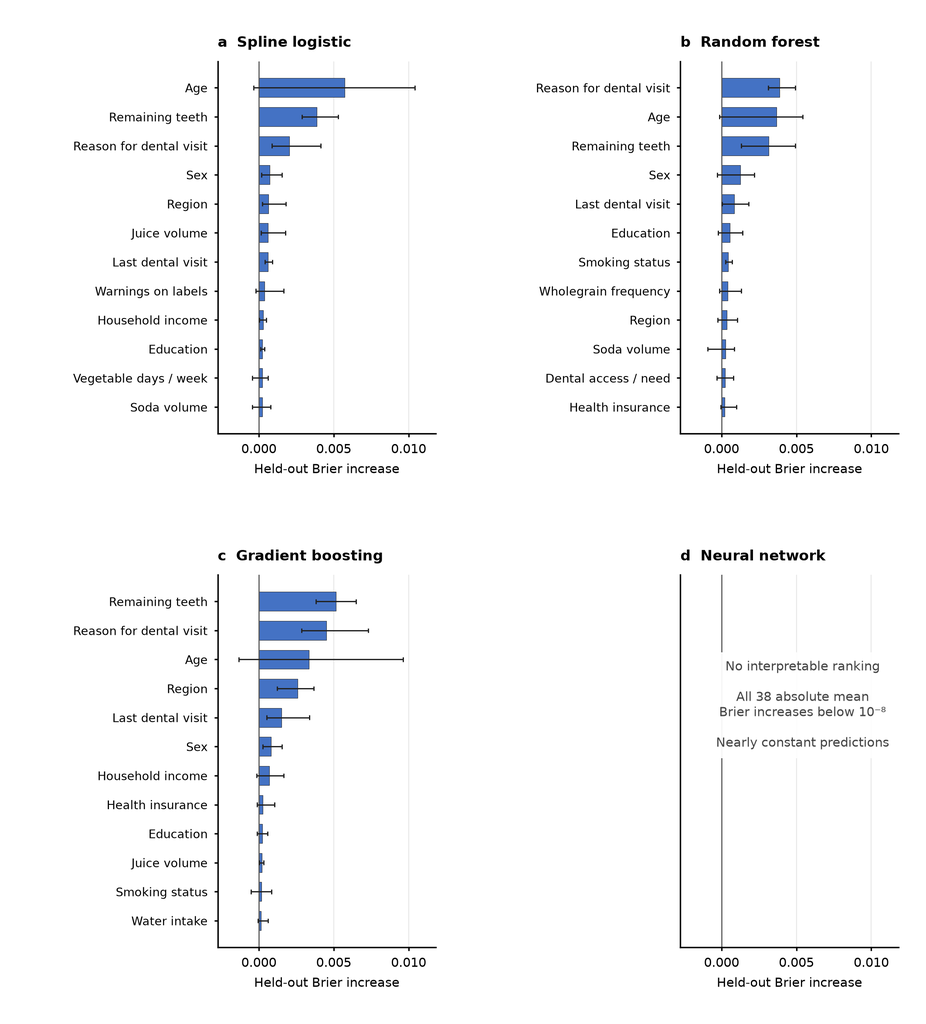

Individual predictor importance in the 38 predictors scenario. The 12 largest signed mean importances are shown for each 38-predictor model; all 38 constructs remain fitted. Blue horizontal bars preserve the visual line of the earlier manuscript. Bars are means of held-out Brier increases after marginal permutation of each raw variable, with five perturbations per outer fold and weighting by fold expansion totals. Whiskers are the minimum and maximum fold means, not confidence intervals. A positive value indicates deterioration after perturbation; a negative value indicates improvement. Correlated predictors may share information, and permutation can create unusual combinations. The scores describe reliance of these fitted classifiers, not causal effects, protective directions or percentages of disease explained. Neural results below absolute mean Brier 10⁻⁸ are marked as numerically near zero; this reporting rule was adopted after observing nearly constant predictions and is not a significance threshold. Neural ranks, sign fractions and AUC permutation scores are not interpreted; all raw signed values remain available in the supplementary results.

Complete four-model and classical-only numeric agreement inventories.

| feature | Description | models | models_with_positive_mean | models_positive_in_at_least_four_folds | models_in_top10 | median_overall_rank | best_overall_rank | worst_overall_rank | classical_models | classical_models_with_positive_mean | classical_models_positive_in_at_least_four_folds | classical_models_in_top10 | classical_median_overall_rank | classical_best_overall_rank | classical_worst_overall_rank |
| --- | --- | --- | --- | --- | --- | --- | --- | --- | --- | --- | --- | --- | --- | --- | --- |
| oral_health_selfrating | Overall self-rated oral health | 4 | 4 | 4 | 4 | 1.0 | 1.0 | 2.0 | 3 | 3 | 3 | 3 | 1.0 | 1.0 | 2.0 |
| age | Age at survey | 4 | 3 | 3 | 3 | 3.0 | 1.0 | 42.0 | 3 | 3 | 3 | 3 | 2.0 | 1.0 | 4.0 |
| dental_visit_reason | Main reason for the most recent dental visit | 4 | 4 | 4 | 4 | 3.0 | 3.0 | 4.0 | 3 | 3 | 3 | 3 | 3.0 | 3.0 | 4.0 |
| teeth_remaining | Total remaining teeth, upper plus lower jaw | 4 | 4 | 3 | 3 | 3.5 | 2.0 | 21.0 | 3 | 3 | 3 | 3 | 3.0 | 2.0 | 4.0 |
| region | Survey region (2016 boundaries) | 4 | 4 | 3 | 2 | 8.5 | 5.0 | 24.0 | 3 | 3 | 2 | 2 | 5.0 | 5.0 | 12.0 |
| sex | Recorded sex | 4 | 4 | 4 | 4 | 5.5 | 5.0 | 7.0 | 3 | 3 | 3 | 3 | 6.0 | 5.0 | 7.0 |
| dental_visit | Time since last dental visit | 4 | 4 | 4 | 4 | 8.0 | 6.0 | 9.0 | 3 | 3 | 3 | 3 | 8.0 | 6.0 | 8.0 |
| health_insurance | Participant's health insurance system, including public insurance group | 4 | 2 | 3 | 2 | 19.5 | 7.0 | 33.0 | 3 | 2 | 2 | 2 | 10.0 | 7.0 | 33.0 |
| oral_eating | Frequency of discomfort from teeth or dentures when eating | 4 | 3 | 3 | 1 | 14.5 | 9.0 | 36.0 | 3 | 3 | 2 | 1 | 11.0 | 9.0 | 18.0 |
| smoking_status | Self-reported current daily, occasional, former or never cigarette smoking | 4 | 2 | 2 | 1 | 20.5 | 10.0 | 33.0 | 3 | 2 | 2 | 1 | 11.0 | 10.0 | 30.0 |
| education | Low <8, intermediate 8–12, high >=13 years of schooling | 4 | 4 | 3 | 1 | 12.0 | 9.0 | 26.0 | 3 | 3 | 3 | 1 | 12.0 | 9.0 | 12.0 |
| income_band | Monthly net income of the entire household, in questionnaire bands | 4 | 3 | 3 | 1 | 14.0 | 9.0 | 32.0 | 3 | 3 | 3 | 1 | 13.0 | 9.0 | 15.0 |
| dairy_type | Usual dairy fat content, with structural category for nonconsumers | 4 | 3 | 0 | 0 | 18.5 | 13.0 | 38.0 | 3 | 2 | 0 | 0 | 14.0 | 13.0 | 38.0 |
| oral_pain | Frequency of suffering or pain attributed to teeth or dentures | 4 | 3 | 2 | 0 | 12.5 | 11.0 | 40.0 | 3 | 2 | 1 | 0 | 14.0 | 11.0 | 40.0 |
| diabetes_reported | Ever told by a health professional that the participant had diabetes | 4 | 4 | 1 | 0 | 15.0 | 14.0 | 24.0 | 3 | 3 | 1 | 0 | 15.0 | 15.0 | 24.0 |
| juice_glasses_daily | Estimated daily juice volume | 4 | 3 | 2 | 1 | 18.5 | 7.0 | 39.0 | 3 | 3 | 2 | 1 | 16.0 | 7.0 | 21.0 |
| vegetable_days | Vegetable consumption days in a typical week | 4 | 3 | 3 | 0 | 17.0 | 16.0 | 27.0 | 3 | 2 | 2 | 0 | 17.0 | 17.0 | 27.0 |
| legumes | Legume consumption frequency | 4 | 2 | 1 | 0 | 26.0 | 18.0 | 41.0 | 3 | 2 | 1 | 0 | 19.0 | 18.0 | 33.0 |
| soda_frequency | Sugar-sweetened soda consumption frequency converted to times/day | 4 | 2 | 0 | 0 | 23.0 | 13.0 | 32.0 | 3 | 2 | 0 | 0 | 19.0 | 13.0 | 32.0 |
| rural_water_consumption | Consumed well, spring or rural drinking water during the previous week for drinking/cooking; not bottled water or fluoride concentration | 4 | 1 | 1 | 0 | 23.0 | 18.0 | 28.0 | 3 | 1 | 1 | 0 | 20.0 | 18.0 | 26.0 |
| oil | Most frequently used cooking oil/fat | 4 | 2 | 0 | 0 | 20.5 | 20.0 | 29.0 | 3 | 1 | 0 | 0 | 21.0 | 20.0 | 29.0 |
| soda_glasses_daily | Estimated daily soda volume | 4 | 3 | 0 | 1 | 19.0 | 4.0 | 32.0 | 3 | 2 | 0 | 0 | 22.0 | 16.0 | 32.0 |
| oral_social | Frequency of interference with social relationships from teeth or dentures | 4 | 3 | 2 | 0 | 24.0 | 14.0 | 28.0 | 3 | 2 | 1 | 0 | 23.0 | 14.0 | 28.0 |
| wholegrain | Wholegrain consumption frequency | 4 | 3 | 0 | 0 | 19.5 | 15.0 | 29.0 | 3 | 2 | 0 | 0 | 23.0 | 16.0 | 29.0 |
| juice_frequency | Sugar-sweetened juice consumption frequency converted to times/day | 4 | 2 | 3 | 1 | 26.0 | 8.0 | 44.0 | 3 | 2 | 3 | 1 | 24.0 | 8.0 | 28.0 |
| dairy_frequency | Dairy consumption frequency | 4 | 2 | 0 | 0 | 31.5 | 20.0 | 39.0 | 3 | 2 | 0 | 0 | 25.0 | 20.0 | 39.0 |
| indigenous | Self-reported membership/ancestry of a recognized indigenous people | 4 | 0 | 0 | 0 | 26.0 | 20.0 | 37.0 | 3 | 0 | 0 | 0 | 25.0 | 20.0 | 27.0 |
| oral_daily_activities | Frequency of interference with daily activities from teeth or dentures | 4 | 1 | 1 | 0 | 28.5 | 22.0 | 34.0 | 3 | 1 | 1 | 0 | 26.0 | 22.0 | 31.0 |
| rural | Urban/rural residence | 4 | 1 | 0 | 0 | 28.5 | 19.0 | 33.0 | 3 | 1 | 0 | 0 | 27.0 | 19.0 | 33.0 |
| dental_access | Dental care received or unmet need during the previous six months | 4 | 2 | 2 | 1 | 25.0 | 6.0 | 36.0 | 3 | 1 | 1 | 1 | 28.0 | 6.0 | 36.0 |
| label_health | Frequency of checking/considering package health | 4 | 2 | 0 | 0 | 23.0 | 12.0 | 43.0 | 3 | 1 | 0 | 0 | 29.0 | 17.0 | 43.0 |
| fruit_portions | Fruit portions on a consumption day; zero for nonconsumers | 4 | 1 | 0 | 0 | 34.5 | 20.0 | 43.0 | 3 | 1 | 0 | 0 | 31.0 | 20.0 | 38.0 |
| label_brand | Frequency of checking/considering package brand | 4 | 1 | 0 | 0 | 30.5 | 19.0 | 35.0 | 3 | 0 | 0 | 0 | 31.0 | 30.0 | 35.0 |
| born_chile | Born in Chile | 4 | 1 | 1 | 0 | 26.0 | 18.0 | 38.0 | 3 | 0 | 0 | 0 | 32.0 | 20.0 | 38.0 |
| label_nutrition | Frequency of checking/considering package nutrition | 4 | 1 | 1 | 1 | 34.5 | 6.0 | 43.0 | 3 | 0 | 0 | 0 | 35.0 | 34.0 | 43.0 |
| water | Self-reported glasses of water per day; water source/fluoride exposure not identified | 4 | 2 | 0 | 1 | 30.5 | 7.0 | 43.0 | 3 | 1 | 0 | 0 | 35.0 | 26.0 | 43.0 |
| household_water_source | Household supply: public network vs other; not a measure of fluoride exposure | 4 | 0 | 0 | 0 | 33.5 | 20.0 | 40.0 | 3 | 0 | 0 | 0 | 36.0 | 20.0 | 40.0 |
| label_discounts | Frequency of checking/considering package discounts | 4 | 1 | 0 | 1 | 33.5 | 8.0 | 39.0 | 3 | 0 | 0 | 0 | 37.0 | 30.0 | 39.0 |
| oral_speech | Frequency of discomfort from teeth or dentures when speaking | 4 | 0 | 0 | 0 | 36.0 | 34.0 | 39.0 | 3 | 0 | 0 | 0 | 37.0 | 34.0 | 39.0 |
| vegetable_portions | Vegetable portions on a consumption day; zero for nonconsumers | 4 | 0 | 0 | 0 | 38.5 | 34.0 | 41.0 | 3 | 0 | 0 | 0 | 37.0 | 34.0 | 41.0 |
| label_ingredients | Frequency of checking/considering package ingredients | 4 | 1 | 0 | 1 | 30.0 | 10.0 | 42.0 | 3 | 0 | 0 | 0 | 40.0 | 20.0 | 42.0 |
| label_warnings | Frequency of checking/considering package warnings | 4 | 2 | 0 | 2 | 25.5 | 2.0 | 41.0 | 3 | 1 | 0 | 1 | 41.0 | 10.0 | 41.0 |
| fruit_days | Fruit consumption days in a typical week | 4 | 1 | 0 | 0 | 39.0 | 13.0 | 44.0 | 3 | 0 | 0 | 0 | 42.0 | 36.0 | 44.0 |
| fish | Fish/seafood consumption frequency | 4 | 1 | 0 | 0 | 43.0 | 17.0 | 44.0 | 3 | 0 | 0 | 0 | 44.0 | 42.0 | 44.0 |

Four-model ranks retain the near-zero neural contributions for reproducibility and are not used as evidence of consensus. The main interpretive agreement view uses the three classical families. No model is removed from performance comparisons.

Complete individual importance for all eight variants.

| Model | Variable | Description | Mean Brier increase | Fold minimum | Fold maximum | Mean AUC decrease | Rank by mean Brier increase | Median fold rank | Fraction of positive folds | Fraction among fold top ten |
| --- | --- | --- | --- | --- | --- | --- | --- | --- | --- | --- |
| Histogram boosting: 38 constructs; excluding S6 | teeth_remaining | Total remaining teeth, upper plus lower jaw | 0.005139 | 0.003804 | 0.006478 | 0.0292 | 1.0 | 2.0 | 1.0 | 1.0 |
| Histogram boosting: 38 constructs; excluding S6 | dental_visit_reason | Main reason for the most recent dental visit | 0.004512 | 0.002854 | 0.007305 | 0.0236 | 2.0 | 2.0 | 1.0 | 1.0 |
| Histogram boosting: 38 constructs; excluding S6 | age | Age at survey | 0.003334 | -0.001339 | 0.009621 | 0.0190 | 3.0 | 3.0 | 0.8 | 0.8 |
| Histogram boosting: 38 constructs; excluding S6 | region | Survey region (2016 boundaries) | 0.002599 | 0.001230 | 0.003672 | 0.0129 | 4.0 | 4.0 | 1.0 | 1.0 |
| Histogram boosting: 38 constructs; excluding S6 | dental_visit | Time since last dental visit | 0.001510 | 0.000509 | 0.003374 | 0.0084 | 5.0 | 5.0 | 1.0 | 1.0 |
| Histogram boosting: 38 constructs; excluding S6 | sex | Recorded sex | 0.000809 | 0.000253 | 0.001549 | 0.0057 | 6.0 | 7.0 | 1.0 | 0.8 |
| Histogram boosting: 38 constructs; excluding S6 | income_band | Monthly net income of the entire household, in questionnaire bands | 0.000702 | -0.000156 | 0.001660 | 0.0033 | 7.0 | 8.0 | 0.8 | 0.8 |
| Histogram boosting: 38 constructs; excluding S6 | health_insurance | Participant's health insurance system, including public insurance group | 0.000250 | -0.000107 | 0.001035 | 0.0022 | 8.0 | 11.0 | 0.8 | 0.4 |
| Histogram boosting: 38 constructs; excluding S6 | education | Low <8, intermediate 8–12, high >=13 years of schooling | 0.000220 | -0.000125 | 0.000570 | 0.0017 | 9.0 | 11.0 | 0.8 | 0.4 |
| Histogram boosting: 38 constructs; excluding S6 | juice_glasses_daily | Estimated daily juice volume | 0.000191 | 0.000039 | 0.000332 | 0.0009 | 10.0 | 12.0 | 1.0 | 0.2 |
| Histogram boosting: 38 constructs; excluding S6 | smoking_status | Self-reported current daily, occasional, former or never cigarette smoking | 0.000162 | -0.000514 | 0.000830 | 0.0015 | 11.0 | 12.0 | 0.6 | 0.4 |
| Histogram boosting: 38 constructs; excluding S6 | water | Self-reported glasses of water per day; water source/fluoride exposure not identified | 0.000137 | -0.000048 | 0.000618 | 0.0005 | 12.0 | 13.0 | 0.6 | 0.2 |
| Histogram boosting: 38 constructs; excluding S6 | label_brand | Frequency of checking/considering package brand | 0.000133 | -0.000015 | 0.000401 | 0.0007 | 13.0 | 15.0 | 0.4 | 0.0 |
| Histogram boosting: 38 constructs; excluding S6 | rural_water_consumption | Consumed well, spring or rural drinking water during the previous week for drinking/cooking; not bottled water or fluoride concentration | 0.000098 | 0.000000 | 0.000475 | 0.0002 | 14.0 | 16.0 | 0.2 | 0.2 |
| Histogram boosting: 38 constructs; excluding S6 | dental_access | Dental care received or unmet need during the previous six months | 0.000088 | -0.000265 | 0.000801 | -0.0005 | 15.0 | 18.0 | 0.2 | 0.2 |
| Histogram boosting: 38 constructs; excluding S6 | soda_glasses_daily | Estimated daily soda volume | 0.000085 | -0.001455 | 0.001138 | 0.0010 | 16.0 | 19.0 | 0.6 | 0.4 |
| Histogram boosting: 38 constructs; excluding S6 | legumes | Legume consumption frequency | 0.000043 | 0.000000 | 0.000115 | 0.0002 | 17.0 | 16.0 | 0.6 | 0.0 |
| Histogram boosting: 38 constructs; excluding S6 | label_discounts | Frequency of checking/considering package discounts | 0.000034 | -0.000660 | 0.000562 | -0.0004 | 18.0 | 14.0 | 0.6 | 0.2 |
| Histogram boosting: 38 constructs; excluding S6 | oil | Most frequently used cooking oil/fat | 0.000014 | 0.000000 | 0.000069 | 0.0001 | 19.0 | 17.0 | 0.2 | 0.0 |
| Histogram boosting: 38 constructs; excluding S6 | born_chile | Born in Chile | 0.000000 | 0.000000 | 0.000000 | 0.0000 | 20.0 | 17.0 | 0.0 | 0.0 |
| Histogram boosting: 38 constructs; excluding S6 | indigenous | Self-reported membership/ancestry of a recognized indigenous people | 0.000000 | 0.000000 | 0.000000 | 0.0000 | 20.0 | 17.0 | 0.0 | 0.0 |
| Histogram boosting: 38 constructs; excluding S6 | label_health | Frequency of checking/considering package health | -0.000018 | -0.000208 | 0.000124 | -0.0000 | 22.0 | 16.0 | 0.2 | 0.0 |
| Histogram boosting: 38 constructs; excluding S6 | vegetable_days | Vegetable consumption days in a typical week | -0.000024 | -0.000546 | 0.000223 | -0.0004 | 23.0 | 13.0 | 0.6 | 0.2 |
| Histogram boosting: 38 constructs; excluding S6 | label_ingredients | Frequency of checking/considering package ingredients | -0.000036 | -0.000115 | 0.000000 | -0.0002 | 24.0 | 18.0 | 0.0 | 0.0 |
| Histogram boosting: 38 constructs; excluding S6 | soda_frequency | Sugar-sweetened soda consumption frequency converted to times/day | -0.000042 | -0.000278 | 0.000359 | 0.0008 | 25.0 | 32.0 | 0.2 | 0.0 |
| Histogram boosting: 38 constructs; excluding S6 | wholegrain | Wholegrain consumption frequency | -0.000065 | -0.000409 | 0.000396 | -0.0002 | 26.0 | 32.0 | 0.2 | 0.0 |
| Histogram boosting: 38 constructs; excluding S6 | diabetes_reported | Ever told by a health professional that the participant had diabetes | -0.000070 | -0.000246 | 0.000034 | -0.0006 | 27.0 | 17.0 | 0.4 | 0.0 |
| Histogram boosting: 38 constructs; excluding S6 | rural | Urban/rural residence | -0.000095 | -0.000457 | 0.000000 | -0.0005 | 28.0 | 17.0 | 0.0 | 0.0 |
| Histogram boosting: 38 constructs; excluding S6 | fruit_days | Fruit consumption days in a typical week | -0.000162 | -0.001025 | 0.000286 | -0.0002 | 29.0 | 28.0 | 0.2 | 0.0 |
| Histogram boosting: 38 constructs; excluding S6 | fruit_portions | Fruit portions on a consumption day; zero for nonconsumers | -0.000168 | -0.002488 | 0.000724 | -0.0001 | 30.0 | 10.0 | 0.8 | 0.6 |

[output cut: 298 more lines]

The full scenarios each contain 44 constructs; complementary scenarios contain 38. All signed effects are retained. Near-zero model ranks and sign frequencies are labelled uninterpretable in this display; exact numeric values remain in the aggregate CSV.

### 8.2 Complete participant profile, missingness and definitions

Observed missingness of all 44 constructs.

| variable | Description | n | missing | percent_missing |
| --- | --- | --- | --- | --- |
| age | Age at survey | 5036 | 0 | 0.000 |
| sex | Recorded sex | 5036 | 0 | 0.000 |
| region | Survey region (2016 boundaries) | 5036 | 0 | 0.000 |
| rural | Urban/rural residence | 5036 | 0 | 0.000 |
| education | Low <8, intermediate 8–12, high >=13 years of schooling | 5036 | 38 | 0.755 |
| indigenous | Self-reported membership/ancestry of a recognized indigenous people | 5036 | 0 | 0.000 |
| born_chile | Born in Chile | 5036 | 0 | 0.000 |
| teeth_remaining | Total remaining teeth, upper plus lower jaw | 5036 | 0 | 0.000 |
| income_band | Monthly net income of the entire household, in questionnaire bands | 5036 | 755 | 14.992 |
| health_insurance | Participant's health insurance system, including public insurance group | 5036 | 52 | 1.033 |
| smoking_status | Self-reported current daily, occasional, former or never cigarette smoking | 5036 | 0 | 0.000 |
| diabetes_reported | Ever told by a health professional that the participant had diabetes | 5036 | 43 | 0.854 |
| dental_visit | Time since last dental visit | 5036 | 0 | 0.000 |
| dental_visit_reason | Main reason for the most recent dental visit | 5036 | 193 | 3.832 |
| dental_access | Dental care received or unmet need during the previous six months | 5036 | 196 | 3.892 |
| household_water_source | Household supply: public network vs other; not a measure of fluoride exposure | 5036 | 6 | 0.119 |
| rural_water_consumption | Consumed well, spring or rural drinking water during the previous week for drinking/cooking; not bottled water or fluoride concentration | 5036 | 1 | 0.020 |
| oral_health_selfrating | Overall self-rated oral health | 5036 | 0 | 0.000 |
| oral_pain | Frequency of suffering or pain attributed to teeth or dentures | 5036 | 0 | 0.000 |
| oral_speech | Frequency of discomfort from teeth or dentures when speaking | 5036 | 0 | 0.000 |
| oral_eating | Frequency of discomfort from teeth or dentures when eating | 5036 | 0 | 0.000 |
| oral_daily_activities | Frequency of interference with daily activities from teeth or dentures | 5036 | 0 | 0.000 |
| oral_social | Frequency of interference with social relationships from teeth or dentures | 5036 | 0 | 0.000 |
| fish | Fish/seafood consumption frequency | 5036 | 0 | 0.000 |
| dairy_frequency | Dairy consumption frequency | 5036 | 0 | 0.000 |
| dairy_type | Usual dairy fat content, with structural category for nonconsumers | 5036 | 0 | 0.000 |
| wholegrain | Wholegrain consumption frequency | 5036 | 0 | 0.000 |
| legumes | Legume consumption frequency | 5036 | 0 | 0.000 |
| fruit_days | Fruit consumption days in a typical week | 5036 | 0 | 0.000 |
| fruit_portions | Fruit portions on a consumption day; zero for nonconsumers | 5036 | 0 | 0.000 |
| vegetable_days | Vegetable consumption days in a typical week | 5036 | 0 | 0.000 |
| vegetable_portions | Vegetable portions on a consumption day; zero for nonconsumers | 5036 | 0 | 0.000 |
| water | Self-reported glasses of water per day; water source/fluoride exposure not identified | 5036 | 4 | 0.079 |
| soda_frequency | Sugar-sweetened soda consumption frequency converted to times/day | 5036 | 0 | 0.000 |
| juice_frequency | Sugar-sweetened juice consumption frequency converted to times/day | 5036 | 0 | 0.000 |
| oil | Most frequently used cooking oil/fat | 5036 | 0 | 0.000 |
| soda_glasses_daily | Estimated daily soda volume | 5036 | 3 | 0.060 |
| juice_glasses_daily | Estimated daily juice volume | 5036 | 2 | 0.040 |
| label_ingredients | Frequency of checking/considering package ingredients | 5036 | 0 | 0.000 |
| label_nutrition | Frequency of checking/considering package nutrition | 5036 | 0 | 0.000 |
| label_warnings | Frequency of checking/considering package warnings | 5036 | 0 | 0.000 |
| label_health | Frequency of checking/considering package health | 5036 | 0 | 0.000 |
| label_brand | Frequency of checking/considering package brand | 5036 | 0 | 0.000 |
| label_discounts | Frequency of checking/considering package discounts | 5036 | 0 | 0.000 |

Predictor missingness never removes an eligible participant from validation. Outcomes are not imputed.

Source definitions and deterministic derivations.

| variable | description | raw_variables | units | missing_and_derivation_rule |
| --- | --- | --- | --- | --- |
| age | Age at survey | Edad | years | Negative special codes and nonfinite values become missing. Missing values retained; categorical codes mapped without imposing linear spacing. |
| sex | Recorded sex | Sexo | category | Negative special codes and nonfinite values become missing. Missing values retained; categorical codes mapped without imposing linear spacing. |
| region | Survey region (2016 boundaries) | Region | category | Negative special codes and nonfinite values become missing. Missing values retained; categorical codes mapped without imposing linear spacing. |
| rural | Urban/rural residence | Zona | category | Negative special codes and nonfinite values become missing. Missing values retained; categorical codes mapped without imposing linear spacing. |
| education | Low <8, intermediate 8–12, high >=13 years of schooling | NEDU1_MINSAL_1 | category | Negative special codes and nonfinite values become missing. Missing values retained; categorical codes mapped without imposing linear spacing. |
| indigenous | Self-reported membership/ancestry of a recognized indigenous people | c6 | category | Negative special codes and nonfinite values become missing. Missing values retained; categorical codes mapped without imposing linear spacing. |
| born_chile | Born in Chile | c1 | category | Negative special codes and nonfinite values become missing. Missing values retained; categorical codes mapped without imposing linear spacing. |
| teeth_remaining | Total remaining teeth, upper plus lower jaw | m5p3 + m5p6 | teeth | Negative special codes and nonfinite values become missing. Add both jaw counts only if both observed; each jaw must be integer 0–16. |
| income_band | Monthly net income of the entire household, in questionnaire bands | as27 + as28 | household CLP/month, category | Negative special codes and nonfinite values are missing. Use nonnegative as27 in CLP/month and the ten fixed lower bounds; otherwise use as28 codes 1–11. Bounds are left-inclusive, including 1,573,000… |
| health_insurance | Participant's health insurance system, including public insurance group | as5_1 | category | Negative special codes and nonfinite values are missing. Preserve categories and unexplained missingness; no fitted transformation. |
| smoking_status | Self-reported current daily, occasional, former or never cigarette smoking | ta3 | category | Negative special codes and nonfinite values are missing. Preserve categories and unexplained missingness; no fitted transformation. |
| diabetes_reported | Ever told by a health professional that the participant had diabetes | di3 | category | Negative special codes and nonfinite values are missing. di3=3 (does not remember) is missing, although its numeric code is positive. |
| dental_visit | Time since last dental visit | sb2 | category | Negative special codes and nonfinite values become missing. Missing values retained; categorical codes mapped without imposing linear spacing. |
| dental_visit_reason | Main reason for the most recent dental visit | sb2 + sb3 | category | Negative special codes and nonfinite values are missing. sb2=6 establishes structural 'Never visited'; otherwise unknown/missing sb3 stays missing. A substantive sb3 response with sb2=6 is an inconsis… |
| dental_access | Dental care received or unmet need during the previous six months | sb4 | category | Negative special codes and nonfinite values are missing. All three negative special codes, including -7777 (not applicable), remain missing; do not interpret missing as no care. |
| household_water_source | Household supply: public network vs other; not a measure of fluoride exposure | as29 | category | Negative special codes and nonfinite values become missing. Missing values retained; categorical codes mapped without imposing linear spacing. |
| rural_water_consumption | Consumed well, spring or rural drinking water during the previous week for drinking/cooking; not bottled water or fluoride concentration | m8p13 | category | Negative special codes and nonfinite values become missing. Missing values retained; categorical codes mapped without imposing linear spacing. |
| oral_health_selfrating | Overall self-rated oral health | sb1 | category | Negative special codes and nonfinite values are missing. Preserve categories and unexplained missingness; no fitted transformation. |
| oral_pain | Frequency of suffering or pain attributed to teeth or dentures | sb5_2 | category | Negative special codes and nonfinite values are missing. Preserve categories and unexplained missingness; no fitted transformation. |
| oral_speech | Frequency of discomfort from teeth or dentures when speaking | sb5_1 | category | Negative special codes and nonfinite values are missing. Preserve categories and unexplained missingness; no fitted transformation. |
| oral_eating | Frequency of discomfort from teeth or dentures when eating | sb5_3 | category | Negative special codes and nonfinite values are missing. Preserve categories and unexplained missingness; no fitted transformation. |
| oral_daily_activities | Frequency of interference with daily activities from teeth or dentures | sb5_4 | category | Negative special codes and nonfinite values are missing. Preserve categories and unexplained missingness; no fitted transformation. |
| oral_social | Frequency of interference with social relationships from teeth or dentures | sb5_5 | category | Negative special codes and nonfinite values are missing. Preserve categories and unexplained missingness; no fitted transformation. |
| fish | Fish/seafood consumption frequency | die1a | category | Negative special codes and nonfinite values become missing. Missing values retained; categorical codes mapped without imposing linear spacing. |
| dairy_frequency | Dairy consumption frequency | die2 | category | Negative special codes and nonfinite values become missing. Missing values retained; categorical codes mapped without imposing linear spacing. |
| dairy_type | Usual dairy fat content, with structural category for nonconsumers | die2 + die3 | category | Negative special codes and nonfinite values become missing. If die2=7 set 'No dairy'; otherwise missing die3 remains missing. |
| wholegrain | Wholegrain consumption frequency | die4 | category | Negative special codes and nonfinite values become missing. Missing values retained; categorical codes mapped without imposing linear spacing. |
| legumes | Legume consumption frequency | die5 | category | Negative special codes and nonfinite values become missing. Missing values retained; categorical codes mapped without imposing linear spacing. |
| fruit_days | Fruit consumption days in a typical week | die6 | days/week | Negative special codes and nonfinite values become missing. Missing values retained; categorical codes mapped without imposing linear spacing. |
| fruit_portions | Fruit portions on a consumption day; zero for nonconsumers | die6 + die7 | portions/consumption day | Negative special codes and nonfinite values become missing. If die6=0 set 0; otherwise preserve missing die7. Do not clip large values. |
| vegetable_days | Vegetable consumption days in a typical week | die8 | days/week | Negative special codes and nonfinite values become missing. Missing values retained; categorical codes mapped without imposing linear spacing. |
| vegetable_portions | Vegetable portions on a consumption day; zero for nonconsumers | die8 + die9 | portions/consumption day | Negative special codes and nonfinite values become missing. If die8=0 set 0; otherwise preserve missing die9. Do not clip large values. |
| water | Self-reported glasses of water per day; water source/fluoride exposure not identified | die11 | glasses/day | Negative special codes and nonfinite values become missing. Preserve 0–50 glasses; code 51='other value, specify' is unquantified and missing; no clipping. |
| soda_frequency | Sugar-sweetened soda consumption frequency converted to times/day | die12_cantidad + die12_unidad | times/day | Negative special codes and nonfinite values become missing. Quantity / (1,7,30) for unit (1,2,3); unit4 nonconsumer=0, unknown/missing unit remains missing. |
| juice_frequency | Sugar-sweetened juice consumption frequency converted to times/day | die13_cantidad + die13_unidad | times/day | Negative special codes and nonfinite values become missing. Quantity / (1,7,30) for unit (1,2,3); unit4 nonconsumer=0, unknown/missing unit remains missing. |
| oil | Most frequently used cooking oil/fat | die14 | category | Negative special codes and nonfinite values become missing. Missing values retained; categorical codes mapped without imposing linear spacing. |
| soda_glasses_daily | Estimated daily soda volume | die12_cantidad + die12_unidad + die12e | glasses/day | Negative special codes and nonfinite values become missing. Daily frequency * die12e; nonconsumer=0 even if glasses/occasion missing; no clipping. |
| juice_glasses_daily | Estimated daily juice volume | die13_cantidad + die13_unidad + die13e | glasses/day | Negative special codes and nonfinite values become missing. Daily frequency * die13e; nonconsumer=0 even if glasses/occasion missing; no clipping. |
| label_ingredients | Frequency of checking/considering package ingredients | die10_a | category | Negative special codes and nonfinite values become missing. Missing values retained; categorical codes mapped without imposing linear spacing. |
| label_nutrition | Frequency of checking/considering package nutrition | die10_b | category | Negative special codes and nonfinite values become missing. Missing values retained; categorical codes mapped without imposing linear spacing. |
| label_warnings | Frequency of checking/considering package warnings | die10_c | category | Negative special codes and nonfinite values become missing. Missing values retained; categorical codes mapped without imposing linear spacing. |
| label_health | Frequency of checking/considering package health | die10_d | category | Negative special codes and nonfinite values become missing. Missing values retained; categorical codes mapped without imposing linear spacing. |
| label_brand | Frequency of checking/considering package brand | die10_e | category | Negative special codes and nonfinite values become missing. Missing values retained; categorical codes mapped without imposing linear spacing. |
| label_discounts | Frequency of checking/considering package discounts | die10_f | category | Negative special codes and nonfinite values become missing. Missing values retained; categorical codes mapped without imposing linear spacing. |

The literal None category remains distinct from missingness. Income bands remain categorical. Three displayed descriptions are adapted to the current roles; original labels and mappings remain in the source dictionary.

Complete descriptive profile of all 44 constructs.

| domain | variable | level | n | observed_n | missing_n | estimate | ci_low | ci_high | units |
| --- | --- | --- | --- | --- | --- | --- | --- | --- | --- |
| No caries | age | Mean | 2347 | 2347 | 0 | 39.72 | 38.51 | 40.92 | years |
| No caries | age | Missing | 0 | 2347 | 0 | — | — | — | years |
| Caries | age | Mean | 2689 | 2689 | 0 | 43.38 | 42.44 | 44.32 | years |
| Caries | age | Missing | 0 | 2689 | 0 | — | — | — | years |
| Total | age | Mean | 5036 | 5036 | 0 | 41.72 | 40.92 | 42.51 | years |
| Total | age | Missing | 0 | 5036 | 0 | — | — | — | years |
| No caries | sex | Female | 1546 | 2347 | 0 | 53.97 | 50.12 | 57.78 | percent |
| No caries | sex | Male | 801 | 2347 | 0 | 46.03 | 42.22 | 49.88 | percent |
| No caries | sex | Missing | 0 | 2347 | 0 | — | — | — | percent |
| Caries | sex | Female | 1579 | 2689 | 0 | 46.27 | 43.04 | 49.53 | percent |
| Caries | sex | Male | 1110 | 2689 | 0 | 53.73 | 50.47 | 56.96 | percent |
| Caries | sex | Missing | 0 | 2689 | 0 | — | — | — | percent |
| Total | sex | Female | 3125 | 5036 | 0 | 49.76 | 47.39 | 52.13 | percent |
| Total | sex | Male | 1911 | 5036 | 0 | 50.24 | 47.87 | 52.61 | percent |
| Total | sex | Missing | 0 | 5036 | 0 | — | — | — | percent |
| No caries | region | 01 Arica and Parinacota | 154 | 2347 | 0 | 1.40 | 1.13 | 1.74 | percent |
| No caries | region | 02 Tarapaca | 150 | 2347 | 0 | 2.17 | 1.66 | 2.84 | percent |
| No caries | region | 03 Antofagasta | 133 | 2347 | 0 | 4.07 | 3.12 | 5.28 | percent |
| No caries | region | 04 Atacama | 140 | 2347 | 0 | 1.96 | 1.31 | 2.91 | percent |
| No caries | region | 05 Coquimbo | 83 | 2347 | 0 | 3.74 | 2.57 | 5.39 | percent |
| No caries | region | 06 Valparaiso | 293 | 2347 | 0 | 12.63 | 10.63 | 14.93 | percent |
| No caries | region | 07 Metropolitan | 374 | 2347 | 0 | 42.33 | 37.87 | 46.92 | percent |
| No caries | region | 08 O'Higgins | 70 | 2347 | 0 | 2.82 | 1.99 | 3.98 | percent |
| No caries | region | 09 Maule | 117 | 2347 | 0 | 5.96 | 3.88 | 9.05 | percent |
| No caries | region | 10 Biobio | 231 | 2347 | 0 | 10.13 | 8.21 | 12.43 | percent |
| No caries | region | 11 La Araucania | 102 | 2347 | 0 | 5.33 | 4.02 | 7.04 | percent |
| No caries | region | 12 Los Rios | 112 | 2347 | 0 | 1.84 | 1.40 | 2.41 | percent |
| No caries | region | 13 Los Lagos | 97 | 2347 | 0 | 3.83 | 2.74 | 5.33 | percent |
| No caries | region | 14 Aysen | 162 | 2347 | 0 | 0.73 | 0.59 | 0.91 | percent |
| No caries | region | 15 Magallanes and Antarctica | 129 | 2347 | 0 | 1.08 | 0.84 | 1.38 | percent |

[output cut: 621 more lines]

Counts and missingness are unweighted. Category percentages use observed responses within each domain as denominator; numeric estimates are weighted means. Missing rows contain counts only. Boundary confidence intervals may be unidentifiable.

### 8.3 Subgroups, thresholds and model diagnostics

Exploratory survey-weighted subgroup performance.

| Model | variable | level | n | events | auc | brier |
| --- | --- | --- | --- | --- | --- | --- |
| Spline logistic: 38 constructs; excluding S6 | sex | Female | 3125 | 1579 | 0.5798 | 0.2461 |
| Spline logistic: 38 constructs; excluding S6 | sex | Male | 1911 | 1110 | 0.6444 | 0.2305 |
| Spline logistic: 38 constructs; excluding S6 | age_group | 15–24 | 729 | 280 | 0.5428 | 0.2436 |
| Spline logistic: 38 constructs; excluding S6 | age_group | 25–44 | 1569 | 828 | 0.5815 | 0.2416 |
| Spline logistic: 38 constructs; excluding S6 | age_group | 45–64 | 1759 | 1034 | 0.6170 | 0.2319 |
| Spline logistic: 38 constructs; excluding S6 | age_group | 65+ | 979 | 547 | 0.6222 | 0.2343 |
| Spline logistic: 38 constructs; excluding S6 | rural | Rural | 760 | 431 | 0.6356 | 0.2337 |
| Spline logistic: 38 constructs; excluding S6 | rural | Urban | 4276 | 2258 | 0.6155 | 0.2388 |
| Spline logistic: 38 constructs; excluding S6 | education | High | 1179 | 525 | 0.5613 | 0.2472 |
| Spline logistic: 38 constructs; excluding S6 | education | Intermediate | 2811 | 1536 | 0.6263 | 0.2351 |
| Spline logistic: 38 constructs; excluding S6 | education | Low | 1008 | 606 | 0.5991 | 0.2336 |
| Spline logistic: 44 constructs | sex | Female | 3125 | 1579 | 0.6051 | 0.2431 |
| Spline logistic: 44 constructs | sex | Male | 1911 | 1110 | 0.6443 | 0.2289 |
| Spline logistic: 44 constructs | age_group | 15–24 | 729 | 280 | 0.5811 | 0.2406 |
| Spline logistic: 44 constructs | age_group | 25–44 | 1569 | 828 | 0.5922 | 0.2405 |
| Spline logistic: 44 constructs | age_group | 45–64 | 1759 | 1034 | 0.6279 | 0.2303 |
| Spline logistic: 44 constructs | age_group | 65+ | 979 | 547 | 0.6541 | 0.2270 |
| Spline logistic: 44 constructs | rural | Rural | 760 | 431 | 0.6404 | 0.2318 |
| Spline logistic: 44 constructs | rural | Urban | 4276 | 2258 | 0.6271 | 0.2365 |
| Spline logistic: 44 constructs | education | High | 1179 | 525 | 0.5796 | 0.2454 |
| Spline logistic: 44 constructs | education | Intermediate | 2811 | 1536 | 0.6362 | 0.2324 |
| Spline logistic: 44 constructs | education | Low | 1008 | 606 | 0.6056 | 0.2326 |
| Random forest: 38 constructs; excluding S6 | sex | Female | 3125 | 1579 | 0.5717 | 0.2461 |
| Random forest: 38 constructs; excluding S6 | sex | Male | 1911 | 1110 | 0.6426 | 0.2290 |
| Random forest: 38 constructs; excluding S6 | age_group | 15–24 | 729 | 280 | 0.5517 | 0.2437 |
| Random forest: 38 constructs; excluding S6 | age_group | 25–44 | 1569 | 828 | 0.5635 | 0.2439 |
| Random forest: 38 constructs; excluding S6 | age_group | 45–64 | 1759 | 1034 | 0.6474 | 0.2266 |
| Random forest: 38 constructs; excluding S6 | age_group | 65+ | 979 | 547 | 0.6317 | 0.2341 |
| Random forest: 38 constructs; excluding S6 | rural | Rural | 760 | 431 | 0.6518 | 0.2302 |
| Random forest: 38 constructs; excluding S6 | rural | Urban | 4276 | 2258 | 0.6090 | 0.2384 |

[output cut: 58 more lines]

Sex, age, residence and observed education are described without subgroup confidence intervals, heterogeneity tests or formal fairness claims. Missing education is not an observed education category.

Classification at the fixed probability threshold 0.5.

| Model | sensitivity (95% CI) | specificity (95% CI) | ppv (95% CI) | accuracy (95% CI) |
| --- | --- | --- | --- | --- |
| Spline logistic: 44 constructs | 0.717 (0.682 to 0.750) | 0.451 (0.415 to 0.486) | 0.611 (0.578 to 0.644) | 0.596 (0.568 to 0.622) |
| Random forest: 44 constructs | 0.733 (0.700 to 0.765) | 0.443 (0.404 to 0.483) | 0.613 (0.580 to 0.645) | 0.601 (0.573 to 0.629) |
| Histogram boosting: 44 constructs | 0.696 (0.659 to 0.732) | 0.495 (0.456 to 0.535) | 0.624 (0.589 to 0.658) | 0.605 (0.578 to 0.631) |
| Neural network (MLP): 44 constructs | 1.000 (1.000 to 1.000) | 0.000 (0.000 to 0.000) | 0.546 (0.521 to 0.572) | 0.546 (0.521 to 0.572) |
| Spline logistic: 38 constructs; excluding S6 | 0.734 (0.700 to 0.767) | 0.398 (0.360 to 0.436) | 0.595 (0.564 to 0.626) | 0.582 (0.554 to 0.608) |
| Random forest: 38 constructs; excluding S6 | 0.731 (0.701 to 0.764) | 0.417 (0.380 to 0.455) | 0.602 (0.573 to 0.632) | 0.589 (0.566 to 0.612) |
| Histogram boosting: 38 constructs; excluding S6 | 0.683 (0.646 to 0.718) | 0.451 (0.417 to 0.485) | 0.600 (0.568 to 0.633) | 0.578 (0.553 to 0.602) |
| Neural network (MLP): 38 constructs; excluding S6 | 1.000 (1.000 to 1.000) | 0.000 (0.000 to 0.000) | 0.546 (0.521 to 0.572) | 0.546 (0.521 to 0.572) |

The threshold is not optimized or proposed as a clinical rule. The same conditional PSU-bootstrap replicates yield these intervals, with undefined ratios omitted as recorded in model_performance.csv.

Selected settings and outer-fold sample sizes.

| Model | fold | n_train | n_test | selected_params |
| --- | --- | --- | --- | --- |
| Spline logistic: 38 constructs; excluding S6 | 1 | 4030 | 1006 | {"C": 0.001} |
| Spline logistic: 38 constructs; excluding S6 | 2 | 4029 | 1007 | {"C": 0.001} |
| Spline logistic: 38 constructs; excluding S6 | 3 | 4025 | 1011 | {"C": 0.001} |
| Spline logistic: 38 constructs; excluding S6 | 4 | 4029 | 1007 | {"C": 0.001} |
| Spline logistic: 38 constructs; excluding S6 | 5 | 4031 | 1005 | {"C": 0.01} |
| Spline logistic: 44 constructs | 1 | 4030 | 1006 | {"C": 0.01} |
| Spline logistic: 44 constructs | 2 | 4029 | 1007 | {"C": 0.001} |
| Spline logistic: 44 constructs | 3 | 4025 | 1011 | {"C": 0.001} |
| Spline logistic: 44 constructs | 4 | 4029 | 1007 | {"C": 0.001} |
| Spline logistic: 44 constructs | 5 | 4031 | 1005 | {"C": 0.01} |
| Random forest: 38 constructs; excluding S6 | 1 | 4030 | 1006 | {"max_features": "sqrt", "min_samples_leaf": 5} |
| Random forest: 38 constructs; excluding S6 | 2 | 4029 | 1007 | {"max_features": "sqrt", "min_samples_leaf": 5} |
| Random forest: 38 constructs; excluding S6 | 3 | 4025 | 1011 | {"max_features": 0.7, "min_samples_leaf": 100} |
| Random forest: 38 constructs; excluding S6 | 4 | 4029 | 1007 | {"max_features": 0.7, "min_samples_leaf": 100} |
| Random forest: 38 constructs; excluding S6 | 5 | 4031 | 1005 | {"max_features": "sqrt", "min_samples_leaf": 20} |
| Random forest: 44 constructs | 1 | 4030 | 1006 | {"max_features": "sqrt", "min_samples_leaf": 5} |
| Random forest: 44 constructs | 2 | 4029 | 1007 | {"max_features": "sqrt", "min_samples_leaf": 5} |
| Random forest: 44 constructs | 3 | 4025 | 1011 | {"max_features": 0.7, "min_samples_leaf": 50} |
| Random forest: 44 constructs | 4 | 4029 | 1007 | {"max_features": "sqrt", "min_samples_leaf": 20} |
| Random forest: 44 constructs | 5 | 4031 | 1005 | {"max_features": "sqrt", "min_samples_leaf": 20} |
| Histogram boosting: 38 constructs; excluding S6 | 1 | 4030 | 1006 | {"l2_regularization": 1.0, "max_leaf_nodes": 3} |
| Histogram boosting: 38 constructs; excluding S6 | 2 | 4029 | 1007 | {"l2_regularization": 100.0, "max_leaf_nodes": 3} |
| Histogram boosting: 38 constructs; excluding S6 | 3 | 4025 | 1011 | {"l2_regularization": 100.0, "max_leaf_nodes": 3} |
| Histogram boosting: 38 constructs; excluding S6 | 4 | 4029 | 1007 | {"l2_regularization": 100.0, "max_leaf_nodes": 3} |
| Histogram boosting: 38 constructs; excluding S6 | 5 | 4031 | 1005 | {"l2_regularization": 100.0, "max_leaf_nodes": 3} |
| Histogram boosting: 44 constructs | 1 | 4030 | 1006 | {"l2_regularization": 100.0, "max_leaf_nodes": 3} |
| Histogram boosting: 44 constructs | 2 | 4029 | 1007 | {"l2_regularization": 10.0, "max_leaf_nodes": 3} |
| Histogram boosting: 44 constructs | 3 | 4025 | 1011 | {"l2_regularization": 100.0, "max_leaf_nodes": 3} |
| Histogram boosting: 44 constructs | 4 | 4029 | 1007 | {"l2_regularization": 100.0, "max_leaf_nodes": 3} |
| Histogram boosting: 44 constructs | 5 | 4031 | 1005 | {"l2_regularization": 100.0, "max_leaf_nodes": 3} |
| Neural network (MLP): 38 constructs; excluding S6 | 1 | 4030 | 1006 | {"alpha": 10.0, "epochs": 100, "hidden_layer_sizes": [64, 32]} |
| Neural network (MLP): 38 constructs; excluding S6 | 2 | 4029 | 1007 | {"alpha": 10.0, "epochs": 100, "hidden_layer_sizes": [32, 16]} |
| Neural network (MLP): 38 constructs; excluding S6 | 3 | 4025 | 1011 | {"alpha": 10.0, "epochs": 100, "hidden_layer_sizes": [32, 16]} |
| Neural network (MLP): 38 constructs; excluding S6 | 4 | 4029 | 1007 | {"alpha": 10.0, "epochs": 100, "hidden_layer_sizes": [64, 32]} |
| Neural network (MLP): 38 constructs; excluding S6 | 5 | 4031 | 1005 | {"alpha": 10.0, "epochs": 100, "hidden_layer_sizes": [64, 32]} |
| Neural network (MLP): 44 constructs | 1 | 4030 | 1006 | {"alpha": 10.0, "epochs": 100, "hidden_layer_sizes": [32, 16]} |
| Neural network (MLP): 44 constructs | 2 | 4029 | 1007 | {"alpha": 10.0, "epochs": 250, "hidden_layer_sizes": [64, 32]} |
| Neural network (MLP): 44 constructs | 3 | 4025 | 1011 | {"alpha": 10.0, "epochs": 100, "hidden_layer_sizes": [64, 32]} |
| Neural network (MLP): 44 constructs | 4 | 4029 | 1007 | {"alpha": 10.0, "epochs": 100, "hidden_layer_sizes": [32, 16]} |
| Neural network (MLP): 44 constructs | 5 | 4031 | 1005 | {"alpha": 10.0, "epochs": 100, "hidden_layer_sizes": [64, 32]} |

Classical settings are retained. Neural settings are selected only by pooled inner weighted log loss.

Authenticated reconstruction of boosting outer fits.

| model | fold | n_test | maximum_absolute_probability_difference | tolerance | status |
| --- | --- | --- | --- | --- | --- |
| hist_gradient_boosting__context_diet_labels | 1 | 1006 | 0.0 | 1.000000e-12 | verified |
| hist_gradient_boosting__context_diet_labels | 2 | 1007 | 0.0 | 1.000000e-12 | verified |
| hist_gradient_boosting__context_diet_labels | 3 | 1011 | 0.0 | 1.000000e-12 | verified |
| hist_gradient_boosting__context_diet_labels | 4 | 1007 | 0.0 | 1.000000e-12 | verified |
| hist_gradient_boosting__context_diet_labels | 5 | 1005 | 0.0 | 1.000000e-12 | verified |
| hist_gradient_boosting__symptoms_diet_labels | 1 | 1006 | 0.0 | 1.000000e-12 | verified |
| hist_gradient_boosting__symptoms_diet_labels | 2 | 1007 | 0.0 | 1.000000e-12 | verified |
| hist_gradient_boosting__symptoms_diet_labels | 3 | 1011 | 0.0 | 1.000000e-12 | verified |
| hist_gradient_boosting__symptoms_diet_labels | 4 | 1007 | 0.0 | 1.000000e-12 | verified |
| hist_gradient_boosting__symptoms_diet_labels | 5 | 1005 | 0.0 | 1.000000e-12 | verified |

Reconstruction obtains missing held-out importance only. Original probabilities and selected hyperparameters are retained; no retuning occurs.

Training–validation PSU separation.

| level | outer_fold | inner_fold | n_train | n_test | psu_train | psu_test | psu_overlap | n_events_train | n_events_test |
| --- | --- | --- | --- | --- | --- | --- | --- | --- | --- |
| outer | 1 | — | 4030 | 1006 | 860 | 212 | 0 | 2152 | 537 |
| inner | 1 | 1.0 | 2689 | 1341 | 577 | 283 | 0 | 1436 | 716 |
| inner | 1 | 2.0 | 2685 | 1345 | 569 | 291 | 0 | 1435 | 717 |
| inner | 1 | 3.0 | 2686 | 1344 | 574 | 286 | 0 | 1433 | 719 |
| outer | 2 | — | 4029 | 1007 | 853 | 219 | 0 | 2151 | 538 |
| inner | 2 | 1.0 | 2686 | 1343 | 571 | 282 | 0 | 1435 | 716 |
| inner | 2 | 2.0 | 2688 | 1341 | 559 | 294 | 0 | 1435 | 716 |
| inner | 2 | 3.0 | 2684 | 1345 | 576 | 277 | 0 | 1432 | 719 |
| outer | 3 | — | 4025 | 1011 | 861 | 211 | 0 | 2149 | 540 |
| inner | 3 | 1.0 | 2684 | 1341 | 567 | 294 | 0 | 1433 | 716 |
| inner | 3 | 2.0 | 2682 | 1343 | 572 | 289 | 0 | 1432 | 717 |
| inner | 3 | 3.0 | 2684 | 1341 | 583 | 278 | 0 | 1433 | 716 |
| outer | 4 | — | 4029 | 1007 | 856 | 216 | 0 | 2151 | 538 |
| inner | 4 | 1.0 | 2683 | 1346 | 571 | 285 | 0 | 1433 | 718 |
| inner | 4 | 2.0 | 2686 | 1343 | 568 | 288 | 0 | 1433 | 718 |
| inner | 4 | 3.0 | 2689 | 1340 | 573 | 283 | 0 | 1436 | 715 |
| outer | 5 | — | 4031 | 1005 | 858 | 214 | 0 | 2153 | 536 |
| inner | 5 | 1.0 | 2689 | 1342 | 570 | 288 | 0 | 1437 | 716 |
| inner | 5 | 2.0 | 2684 | 1347 | 578 | 280 | 0 | 1432 | 721 |
| inner | 5 | 3.0 | 2689 | 1342 | 568 | 290 | 0 | 1437 | 716 |

Every outer and inner split must have zero PSU overlap. Individual identities and predictions remain private.

Neural probability variation within each held-out fold.

| model | fold | n_test | min_probability | max_probability | probability_range | probability_sd | distinct_probabilities_at_six_decimals | weighted_mean_probability | training_prevalence |
| --- | --- | --- | --- | --- | --- | --- | --- | --- | --- |
| Neural network (MLP): 38 constructs; excluding S6 | 1 | 1006 | 0.55236138 | 0.55236138 | 1.295e-12 | 1.464e-13 | 1 | 0.55236138 | 0.55358376 |
| Neural network (MLP): 38 constructs; excluding S6 | 2 | 1007 | 0.54819801 | 0.54819801 | 5.329e-14 | 8.909e-15 | 1 | 0.54819801 | 0.54757551 |
| Neural network (MLP): 38 constructs; excluding S6 | 3 | 1011 | 0.55020248 | 0.55020248 | 4.436e-12 | 3.639e-13 | 1 | 0.55020248 | 0.54978315 |
| Neural network (MLP): 38 constructs; excluding S6 | 4 | 1007 | 0.53582881 | 0.53582881 | 9.112e-09 | 1.332e-09 | 1 | 0.53582881 | 0.53922022 |
| Neural network (MLP): 38 constructs; excluding S6 | 5 | 1005 | 0.53916282 | 0.53916310 | 2.769e-07 | 1.465e-08 | 1 | 0.53916304 | 0.54177124 |
| Neural network (MLP): 44 constructs | 1 | 1006 | 0.55254562 | 0.55254562 | 3.610e-12 | 5.346e-13 | 1 | 0.55254562 | 0.55358376 |
| Neural network (MLP): 44 constructs | 2 | 1007 | 0.54690203 | 0.54690203 | 6.773e-12 | 7.599e-13 | 1 | 0.54690203 | 0.54757551 |
| Neural network (MLP): 44 constructs | 3 | 1011 | 0.54803571 | 0.54803572 | 4.802e-09 | 4.520e-10 | 1 | 0.54803571 | 0.54978315 |
| Neural network (MLP): 44 constructs | 4 | 1007 | 0.54005967 | 0.54005967 | 3.116e-12 | 5.450e-13 | 1 | 0.54005967 | 0.53922022 |
| Neural network (MLP): 44 constructs | 5 | 1005 | 0.53891679 | 0.53891679 | 7.479e-09 | 1.096e-09 | 1 | 0.53891679 | 0.54177124 |

Within-fold ranges and standard deviations describe the nearly constant predictions. AUC permutation changes can be driven by ordering of tiny numerical differences and are not interpreted as evidence of neural variable importance. Training prevalence is shown as context; no refit or post-result retuning is performed.

Neural training diagnostics.

| model | fold | optimizer_loss_initial | optimizer_loss_final | last_10_epoch_loss_change | warnings |
| --- | --- | --- | --- | --- | --- |
| mlp__context_diet_labels | 1 | 5.008769 | 0.687630 | 0.000282 | [{"category": "ConvergenceWarning", "message": "Stochastic Optimizer: Maximum iterations (100) reached and the optimization hasn't converged yet."}] |
| mlp__context_diet_labels | 2 | 3.206096 | 0.688222 | -0.000575 | [{"category": "ConvergenceWarning", "message": "Stochastic Optimizer: Maximum iterations (100) reached and the optimization hasn't converged yet."}] |
| mlp__context_diet_labels | 3 | 3.268987 | 0.687906 | -0.001146 | [{"category": "ConvergenceWarning", "message": "Stochastic Optimizer: Maximum iterations (100) reached and the optimization hasn't converged yet."}] |
| mlp__context_diet_labels | 4 | 5.105724 | 0.690565 | -0.000192 | [{"category": "ConvergenceWarning", "message": "Stochastic Optimizer: Maximum iterations (100) reached and the optimization hasn't converged yet."}] |
| mlp__context_diet_labels | 5 | 5.148773 | 0.689890 | -0.000019 | [{"category": "ConvergenceWarning", "message": "Stochastic Optimizer: Maximum iterations (100) reached and the optimization hasn't converged yet."}] |
| mlp__symptoms_diet_labels | 1 | 3.397750 | 0.687704 | 0.000256 | [{"category": "ConvergenceWarning", "message": "Stochastic Optimizer: Maximum iterations (100) reached and the optimization hasn't converged yet."}] |
| mlp__symptoms_diet_labels | 2 | 5.090577 | 0.688545 | -0.000171 | [{"category": "ConvergenceWarning", "message": "Stochastic Optimizer: Maximum iterations (250) reached and the optimization hasn't converged yet."}] |
| mlp__symptoms_diet_labels | 3 | 5.186959 | 0.688569 | 0.000545 | [{"category": "ConvergenceWarning", "message": "Stochastic Optimizer: Maximum iterations (100) reached and the optimization hasn't converged yet."}] |
| mlp__symptoms_diet_labels | 4 | 3.284963 | 0.690515 | 0.000280 | [{"category": "ConvergenceWarning", "message": "Stochastic Optimizer: Maximum iterations (100) reached and the optimization hasn't converged yet."}] |
| mlp__symptoms_diet_labels | 5 | 5.168760 | 0.689910 | 0.000386 | [{"category": "ConvergenceWarning", "message": "Stochastic Optimizer: Maximum iterations (100) reached and the optimization hasn't converged yet."}] |

Optimizer losses include regularization and are training diagnostics, not validation performance. Warnings about fixed iteration budgets are retained; no tolerance-based convergence claim is made.

Weighted and unweighted evaluation.

| Model | Weighted AUC | Unweighted AUC | Weighted Brier | Unweighted Brier |
| --- | --- | --- | --- | --- |
| Spline logistic: 44 constructs | 0.630 | 0.640 | 0.2360 | 0.2351 |
| Random forest: 44 constructs | 0.637 | 0.641 | 0.2341 | 0.2348 |
| Histogram boosting: 44 constructs | 0.635 | 0.648 | 0.2347 | 0.2329 |
| Neural network (MLP): 44 constructs | 0.488 | 0.509 | 0.2481 | 0.2490 |
| Spline logistic: 38 constructs; excluding S6 | 0.618 | 0.630 | 0.2383 | 0.2375 |
| Random forest: 38 constructs; excluding S6 | 0.614 | 0.630 | 0.2375 | 0.2365 |
| Histogram boosting: 38 constructs; excluding S6 | 0.612 | 0.636 | 0.2391 | 0.2351 |
| Neural network (MLP): 38 constructs; excluding S6 | 0.488 | 0.511 | 0.2482 | 0.2490 |

Both evaluate the same survey-weighted fits. Unweighted results are descriptive and receive no survey-bootstrap intervals.

### 8.4 Reproducibility

Verified analysis record.

| Record | Value |
| --- | --- |
| Run completed (UTC) | 2026-09-10T20:49:21.104482+00:00 |
| Participants / cases | 5036 / 2689 |
| Constructs / variants / benchmark | 44 / 8 / 1 |
| Outer / inner folds | 5 / 3; PSU-disjoint |
| Conditional bootstrap replicates | 1000 |
| SAV SHA-256 | 9873b421d446190070bfff6495321fb152485c47457692936dbcd18c542eb89a |
| Extension-plan SHA-256 | 16090e46bddec67cd28bbd58f614490383beb2647f2a6e34b81b94760670867e |
| Software | {"numpy": "2.5.3", "pandas": "3.0.5", "scipy": "1.18.1", "sklearn": "1.9.0"} |
| Scope | Exploratory all-predictor importance and regularized neural-network comparison; prior dietary proposal and Andrea correction preserved |

Rendering verifies the exact source paths declared in this run, plan, input provenance, cohort, model manifest, importance completeness, finite neural diagnostics and paired-gain direction. The report reads aggregate tables only.

The fixed extension plan and independent methods review describe this new question and its limits. Aggregate outputs and figure exports occupy `outputs/all_predictors/`; participant records, probabilities, folds and caches remain private. The earlier dietary proposal and Andrea manuscript correction remain separately preserved.